```python
%matplotlib inline
import pycisTopic
pycisTopic.__version__
```

```
'0.1.dev178+g01146fa.d20210318'
```

# Tutorial: scATAC-seq data analysis with pycisTopic

- 0. Installing pycisTopic
- 1. Getting pseudobulk profiles from scRNA-seq annotations
- 2. Inferring consensus peaks
- 3. QC
  - 3a. Sample-level statistics
  - 3b. Barcode level statistics
- 4. Creating a cisTopic object
- 5. Adding metadata to a cisTopic object
- 6. Running scrublet in a cisTopic object
- 7. Run models
- 8. Model selection
- 9. Clustering and visualization
- 10. Topic binarization & qc
- 11. Differentially Accessible Regions (DARs)
- 12. Gene activity
- 13. Label transfer
- 14. Exporting to loom

### 0. Installing pycisTopic

You can easily install pycisTopic from its github repository.

```python
module load Python/3.7.4-GCCcore-6.4.0
git clone https://github.com/aertslab/pycisTopic.git
cd pycisTopic
pip install .
```

```python
import pycisTopic
pycisTopic.__version__
```

```
'0.1.dev143+g58826c1'
```

You can also check function documentation for further information.

```python
from pycisTopic.qc import *
help(profile_tss)
```

[Back to top]

### 1. Getting pseudobulk profiles from scRNA-seq annotations

We will start by loading the barcode metadata from the scRNA-seq analysis. In this case, I will use the annotated loom file, but loading it from a tsv file or similar is also possible (as long as you end up with a similar pd.DataFrame).

```python
# Get metadata from loom file
from loomxpy import SCopeLoom
from pycisTopic.loom import *
path_to_annotated_rna_loom = "/staging/leuven/stg_00002/lcb/cbravo/Multiomics_pipeline/analysis/10x_multiome_brain/output/rna/vsn/add_clusters_scrublet_as_annot/10x_multiome_brain_SCENIC_SCope_output_wAnnot_noDBL.loom"
loom = SCopeLoom.read_loom(path_to_annotated_rna_loom)
cell_data = get_metadata(loom)
```

Importantly, if you are starting from a pandas data frame, the index of your pandas should correspond to BARCODE (e.g. ATGTCTGATAGA-1, additional tags are possible using -; e.g. ATGTCTGATAGA-1-sample_1) and it must contain a 'sample_id' column indicating the sample label fo origin. Let's see how it looks like here. The sample_id for all cells in this tutorial is '10x_multiome_brain'. Alternatively, you can also add a column named 'barcode' to the metadata with the corresponding cell barcodes (in this case the name of the cells will not be used to infer the barcode id).

```python
cell_data
```

|  | leiden_res0.9 | leiden_res0.3 | leiden_res1.2 | leiden_res0.6 | cell_type | sample_id |
| --- | --- | --- | --- | --- | --- | --- |
| AAACAGCCATTATGCG-1-10x_multiome_brain | MOL_1 (1) | MOL (0) | MOL_3 (6) | MOL_1 (0) | MOL | 10x_multiome_brain |
| AAACCAACATAGACCC-1-10x_multiome_brain | MOL_3 (5) | MOL (0) | MOL_4 (4) | MOL_1 (0) | MOL | 10x_multiome_brain |
| AAACCGAAGATGCCTG-1-10x_multiome_brain | INH_VIP (8) | INH_VIP (6) | INH_VIP (10) | INH_VIP (8) | INH_VIP | 10x_multiome_brain |
| AAACCGAAGTTAGCTA-1-10x_multiome_brain | NFOL_1 (0) | NFOL (1) | NFOL_2 (0) | NFOL_2 (1) | NFOL | 10x_multiome_brain |
| AAACCGCGTCTTACTA-1-10x_multiome_brain | MOL_1 (1) | MOL (0) | MOL_2 (2) | MOL_2 (3) | MOL | 10x_multiome_brain |
| ... | ... | ... | ... | ... | ... | ... |
| TTTGTGAAGGGTGAGT-1-10x_multiome_brain | INH_VIP (8) | INH_VIP (6) | INH_VIP (10) | INH_VIP (8) | INH_VIP | 10x_multiome_brain |
| TTTGTGAAGTCAGGCC-1-10x_multiome_brain | AST_CER (2) | AST_CER (2) | AST_CER_1 (7) | AST_CER (2) | AST_CER | 10x_multiome_brain |
| TTTGTGGCATGCTTAG-1-10x_multiome_brain | MOL_1 (1) | MOL (0) | MOL_1 (1) | MOL_1 (0) | MOL | 10x_multiome_brain |
| TTTGTTGGTGATCAGC-1-10x_multiome_brain | NFOL_1 (0) | NFOL (1) | NFOL_1 (11) | NFOL_2 (1) | NFOL | 10x_multiome_brain |
| TTTGTTGGTGATTTGG-1-10x_multiome_brain | INH_SST (7) | INH_SST (5) | INH_SST (9) | INH_SST (7) | INH_SST | 10x_multiome_brain |

2607 rows × 6 columns

In order to produce the bigwig files, we also need to know the overall size of the chromosomes. We can easily download this information from the UCSC.

```python
# Get chromosome sizes (for hg38 here)
import pyranges as pr
import requests
target_url='http://hgdownload.cse.ucsc.edu/goldenPath/hg38/bigZips/hg38.chrom.sizes'
chromsizes=pd.read_csv(target_url, sep='\t', header=None)
chromsizes.columns=['Chromosome', 'End']
chromsizes['Start']=[0]*chromsizes.shape[0]
chromsizes=chromsizes.loc[:,['Chromosome', 'Start', 'End']]
# Exceptionally in this case, to agree with CellRangerARC annotations
chromsizes['Chromosome'] = [chromsizes['Chromosome'][x].replace('v', '.') for x in range(len(chromsizes['Chromosome']))]
chromsizes['Chromosome'] = [chromsizes['Chromosome'][x].split('_')[1] if len(chromsizes['Chromosome'][x].split('_')) > 1 else chromsizes['Chromosome'][x] for x in range(len(chromsizes['Chromosome']))]
chromsizes=pr.PyRanges(chromsizes)
```

Now we have all the ingredients we need to generate the pseudobulk files. With this function we will generate fragments files per group and the corresponding bigwigs. The mandatory input to this function are:

- The annotation dataframe (`input_data`)
- The variable used to group the cells (in this case, 'cell type')
- The chromosome sizes
- The paths to where the bed and bigiwg files will be written
- A dictionary indicating the fragments file corresponsing to each sample. **The sample ids used as keys in this dictionary must match with the sample ids in the annotation data frame!**

```python
from pycisTopic.pseudobulk_peak_calling import *
bw_paths, bed_paths = export_pseudobulk(input_data = cell_data,
                 variable = 'cell_type',
                 chromsizes = chromsizes,
                 bed_path = '/staging/leuven/stg_00002/lcb/cbravo/Multiomics_pipeline/analysis/10x_multiome_brain/output/atac/pycistopic/consensus_peak_calling/pseudobulk_bed_files/',
                 bigwig_path =  '/staging/leuven/stg_00002/lcb/cbravo/Multiomics_pipeline/analysis/10x_multiome_brain/output/atac/pycistopic/consensus_peak_calling/pseudobulk_bw_files/',
                 path_to_fragments = {'10x_multiome_brain':'/staging/leuven/stg_00002/lcb/cbravo/Multiomics_pipeline/analysis/10x_multiome_brain/data/cell-arc/1.0.0/outs/human_brain_3k_atac_fragments.tsv.gz'},
                 n_cpu = 5,
                 normalize_bigwig = True,
                 remove_duplicates = True)
```

```
2021-03-11 20:12:43,005 cisTopic     INFO     Reading fragments from /staging/leuven/stg_00002/lcb/cbravo/Multiomics_pipeline/analysis/10x_multiome_brain/data/cell-arc/1.0.0/outs/human_brain_3k_atac_fragments.tsv.gz
```

```
2021-03-11 20:15:07,051	INFO resource_spec.py:212 -- Starting Ray with 116.5 GiB memory available for workers and up to 53.93 GiB for objects. You can adjust these settings with ray.init(memory=<bytes>, object_store_memory=<bytes>).
2021-03-11 20:15:07,596	WARNING services.py:923 -- Redis failed to start, retrying now.
2021-03-11 20:15:09,191	INFO services.py:1165 -- View the Ray dashboard at localhost:8265
```

```
(pid=22663) 2021-03-11 20:15:26,313 cisTopic     INFO     Creating pseudobulk for AST
(pid=22663) 2021-03-11 20:15:32,227 numexpr.utils INFO     Note: NumExpr detected 36 cores but "NUMEXPR_MAX_THREADS" not set, so enforcing safe limit of 8.
(pid=22662) 2021-03-11 20:15:36,587 cisTopic     INFO     Creating pseudobulk for ASTP
(pid=22662) 2021-03-11 20:15:43,413 numexpr.utils INFO     Note: NumExpr detected 36 cores but "NUMEXPR_MAX_THREADS" not set, so enforcing safe limit of 8.
(pid=22664) 2021-03-11 20:15:47,604 cisTopic     INFO     Creating pseudobulk for AST_CER
(pid=22663) 2021-03-11 20:15:47,675 cisTopic     INFO     AST done!
(pid=22663) 2021-03-11 20:15:56,149 cisTopic     INFO     Creating pseudobulk for ENDO
(pid=22664) 2021-03-11 20:15:58,958 numexpr.utils INFO     Note: NumExpr detected 36 cores but "NUMEXPR_MAX_THREADS" not set, so enforcing safe limit of 8.
(pid=22666) 2021-03-11 20:16:08,471 cisTopic     INFO     Creating pseudobulk for GC
(pid=22663) 2021-03-11 20:16:08,538 cisTopic     INFO     ENDO done!
(pid=22663) 2021-03-11 20:16:17,199 cisTopic     INFO     Creating pseudobulk for GP
(pid=22666) 2021-03-11 20:16:19,491 numexpr.utils INFO     Note: NumExpr detected 36 cores but "NUMEXPR_MAX_THREADS" not set, so enforcing safe limit of 8.
(pid=22662) 2021-03-11 20:16:22,667 cisTopic     INFO     ASTP done!
(pid=22665) 2021-03-11 20:16:29,523 cisTopic     INFO     Creating pseudobulk for INH_PVALB
(pid=22665) 2021-03-11 20:16:37,095 numexpr.utils INFO     Note: NumExpr detected 36 cores but "NUMEXPR_MAX_THREADS" not set, so enforcing safe limit of 8.
(pid=22662) 2021-03-11 20:16:38,866 cisTopic     INFO     Creating pseudobulk for INH_SST
(pid=22665) 2021-03-11 20:16:52,465 cisTopic     INFO     INH_PVALB done!
(pid=22665) 2021-03-11 20:16:59,703 cisTopic     INFO     Creating pseudobulk for INH_VIP
(pid=22663) 2021-03-11 20:17:22,283 cisTopic     INFO     GP done!
(pid=22663) 2021-03-11 20:17:30,255 cisTopic     INFO     Creating pseudobulk for MGL
(pid=22663) 2021-03-11 20:17:58,965 cisTopic     INFO     MGL done!
(pid=22663) 2021-03-11 20:18:06,721 cisTopic     INFO     Creating pseudobulk for MOL
(pid=22662) 2021-03-11 20:18:46,334 cisTopic     INFO     INH_SST done!
(pid=22665) 2021-03-11 20:18:48,640 cisTopic     INFO     INH_VIP done!
(pid=22662) 2021-03-11 20:18:54,203 cisTopic     INFO     Creating pseudobulk for NFOL
(pid=22665) 2021-03-11 20:18:56,513 cisTopic     INFO     Creating pseudobulk for OPC
(pid=22666) 2021-03-11 20:19:30,180 cisTopic     INFO     GC done!
(pid=22664) 2021-03-11 20:19:32,444 cisTopic     INFO     AST_CER done!
(pid=22666) 2021-03-11 20:19:36,890 cisTopic     INFO     Creating pseudobulk for PURK
(pid=22666) 2021-03-11 20:20:14,315 cisTopic     INFO     PURK done!
(pid=22665) 2021-03-11 20:20:23,186 cisTopic     INFO     OPC done!
(pid=22662) 2021-03-11 20:21:37,722 cisTopic     INFO     NFOL done!
(pid=22663) 2021-03-11 20:22:09,681 cisTopic     INFO     MOL done!
```

Let's save the paths dictionaries.

```python
import pickle
with open('/staging/leuven/stg_00002/lcb/cbravo/Multiomics_pipeline/analysis/10x_multiome_brain/output/atac/pycistopic/consensus_peak_calling/pseudobulk_bed_files/bed_paths.pkl', 'wb') as f:
  pickle.dump(bed_paths, f)
```

```python
import pickle
with open('/staging/leuven/stg_00002/lcb/cbravo/Multiomics_pipeline/analysis/10x_multiome_brain/output/atac/pycistopic/consensus_peak_calling/pseudobulk_bed_files/bw_paths.pkl', 'wb') as f:
  pickle.dump(bw_paths, f)
```

[Back to top]

This function can be used with cisTopic objects (as `input_data`), instead of the annotation data frame and the paths to fragments dictionary. You can find an example later.

### 2. Inferring consensus peaks

In the following step, we will use MACS2 to call peaks in each group (in this case, cell type). The default parameters are those recommended for ATAC-seq data.

```python
import os
# Set correct path to run MACS2
os.putenv('MACS2_HOME','/data/leuven/software/biomed/haswell_centos7/2018a/software/MACS2/2.1.2.1-foss-2018a-Python-2.7.16/')
os.putenv('PATH','/data/leuven/software/biomed/haswell_centos7/2018a/software/MACS2/2.1.2.1-foss-2018a-Python-2.7.16/bin:' + os.environ['PATH'])
macs_path='/data/leuven/software/biomed/haswell_centos7/2018a/software/MACS2/2.1.2.1-foss-2018a-Python-2.7.16/bin/macs2'
outdir = '/staging/leuven/stg_00002/lcb/cbravo/Multiomics_pipeline/analysis/test/output/atac/pycistopic/consensus_peak_calling/MACS/'
# Run peak calling
narrow_peaks_dict = peak_calling(macs_path, bed_paths, outdir, genome_size='hs', n_cpu=5, input_format='BEDPE', shift=73, ext_size=146, keep_dup = 'all', q_value = 0.05)
```

```
2021-03-09 13:32:57,311	INFO resource_spec.py:212 -- Starting Ray with 156.79 GiB memory available for workers and up to 71.19 GiB for objects. You can adjust these settings with ray.init(memory=<bytes>, object_store_memory=<bytes>).
2021-03-09 13:32:57,712	WARNING services.py:923 -- Redis failed to start, retrying now.
2021-03-09 13:32:58,257	INFO services.py:1165 -- View the Ray dashboard at localhost:8265
```

```
(pid=8055) 2021-03-09 13:33:41,644 cisTopic     INFO     Calling peaks for AST with /data/leuven/software/biomed/haswell_centos7/2018a/software/MACS2/2.1.2.1-foss-2018a-Python-2.7.16/bin/macs2 callpeak --treatment /staging/leuven/stg_00002/lcb/cbravo/Multiomics_pipeline/analysis/10x_multiome_brain/o…
(pid=8054) 2021-03-09 13:33:41,644 cisTopic     INFO     Calling peaks for GC with /data/leuven/software/biomed/haswell_centos7/2018a/software/MACS2/2.1.2.1-foss-2018a-Python-2.7.16/bin/macs2 callpeak --treatment /staging/leuven/stg_00002/lcb/cbravo/Multiomics_pipeline/analysis/10x_multiome_brain/ou…
(pid=8056) 2021-03-09 13:33:41,644 cisTopic     INFO     Calling peaks for ENDO with /data/leuven/software/biomed/haswell_centos7/2018a/software/MACS2/2.1.2.1-foss-2018a-Python-2.7.16/bin/macs2 callpeak --treatment /staging/leuven/stg_00002/lcb/cbravo/Multiomics_pipeline/analysis/10x_multiome_brain/…
(pid=8053) 2021-03-09 13:33:41,644 cisTopic     INFO     Calling peaks for ASTP with /data/leuven/software/biomed/haswell_centos7/2018a/software/MACS2/2.1.2.1-foss-2018a-Python-2.7.16/bin/macs2 callpeak --treatment /staging/leuven/stg_00002/lcb/cbravo/Multiomics_pipeline/analysis/10x_multiome_brain/…
(pid=8057) 2021-03-09 13:33:41,644 cisTopic     INFO     Calling peaks for AST_CER with /data/leuven/software/biomed/haswell_centos7/2018a/software/MACS2/2.1.2.1-foss-2018a-Python-2.7.16/bin/macs2 callpeak --treatment /staging/leuven/stg_00002/lcb/cbravo/Multiomics_pipeline/analysis/10x_multiome_bra…
(pid=8056) 2021-03-09 13:33:59,113 cisTopic     INFO     ENDO done!
(pid=8056) 2021-03-09 13:33:59,147 cisTopic     INFO     Calling peaks for GP with /data/leuven/software/biomed/haswell_centos7/2018a/software/MACS2/2.1.2.1-foss-2018a-Python-2.7.16/bin/macs2 callpeak --treatment /staging/leuven/stg_00002/lcb/cbravo/Multiomics_pipeline/analysis/10x_multiome_brain/ou…
(pid=8055) 2021-03-09 13:34:13,761 cisTopic     INFO     AST done!
(pid=8055) 2021-03-09 13:34:13,810 cisTopic     INFO     Calling peaks for INH_PVALB with /data/leuven/software/biomed/haswell_centos7/2018a/software/MACS2/2.1.2.1-foss-2018a-Python-2.7.16/bin/macs2 callpeak --treatment /staging/leuven/stg_00002/lcb/cbravo/Multiomics_pipeline/analysis/10x_multiome_b…
(pid=8055) 2021-03-09 13:34:22,471 cisTopic     INFO     INH_PVALB done!
(pid=8055) 2021-03-09 13:34:22,515 cisTopic     INFO     Calling peaks for INH_SST with /data/leuven/software/biomed/haswell_centos7/2018a/software/MACS2/2.1.2.1-foss-2018a-Python-2.7.16/bin/macs2 callpeak --treatment /staging/leuven/stg_00002/lcb/cbravo/Multiomics_pipeline/analysis/10x_multiome_bra…
(pid=8053) 2021-03-09 13:34:24,075 cisTopic     INFO     ASTP done!
(pid=8053) 2021-03-09 13:34:24,128 cisTopic     INFO     Calling peaks for INH_VIP with /data/leuven/software/biomed/haswell_centos7/2018a/software/MACS2/2.1.2.1-foss-2018a-Python-2.7.16/bin/macs2 callpeak --treatment /staging/leuven/stg_00002/lcb/cbravo/Multiomics_pipeline/analysis/10x_multiome_bra…
(pid=8056) 2021-03-09 13:34:56,307 cisTopic     INFO     GP done!
(pid=8056) 2021-03-09 13:34:56,413 cisTopic     INFO     Calling peaks for MGL with /data/leuven/software/biomed/haswell_centos7/2018a/software/MACS2/2.1.2.1-foss-2018a-Python-2.7.16/bin/macs2 callpeak --treatment /staging/leuven/stg_00002/lcb/cbravo/Multiomics_pipeline/analysis/10x_multiome_brain/o…
(pid=8056) 2021-03-09 13:35:33,005 cisTopic     INFO     MGL done!
(pid=8056) 2021-03-09 13:35:33,061 cisTopic     INFO     Calling peaks for MOL with /data/leuven/software/biomed/haswell_centos7/2018a/software/MACS2/2.1.2.1-foss-2018a-Python-2.7.16/bin/macs2 callpeak --treatment /staging/leuven/stg_00002/lcb/cbravo/Multiomics_pipeline/analysis/10x_multiome_brain/o…
(pid=8053) 2021-03-09 13:35:37,244 cisTopic     INFO     INH_VIP done!
(pid=8053) 2021-03-09 13:35:37,340 cisTopic     INFO     Calling peaks for NFOL with /data/leuven/software/biomed/haswell_centos7/2018a/software/MACS2/2.1.2.1-foss-2018a-Python-2.7.16/bin/macs2 callpeak --treatment /staging/leuven/stg_00002/lcb/cbravo/Multiomics_pipeline/analysis/10x_multiome_brain/…
(pid=8054) 2021-03-09 13:35:39,970 cisTopic     INFO     GC done!
(pid=8054) 2021-03-09 13:35:40,059 cisTopic     INFO     Calling peaks for OPC with /data/leuven/software/biomed/haswell_centos7/2018a/software/MACS2/2.1.2.1-foss-2018a-Python-2.7.16/bin/macs2 callpeak --treatment /staging/leuven/stg_00002/lcb/cbravo/Multiomics_pipeline/analysis/10x_multiome_brain/o…
(pid=8057) 2021-03-09 13:35:40,997 cisTopic     INFO     AST_CER done!
(pid=8057) 2021-03-09 13:35:41,092 cisTopic     INFO     Calling peaks for PURK with /data/leuven/software/biomed/haswell_centos7/2018a/software/MACS2/2.1.2.1-foss-2018a-Python-2.7.16/bin/macs2 callpeak --treatment /staging/leuven/stg_00002/lcb/cbravo/Multiomics_pipeline/analysis/10x_multiome_brain/…
(pid=8055) 2021-03-09 13:35:46,147 cisTopic     INFO     INH_SST done!
(pid=8057) 2021-03-09 13:36:05,673 cisTopic     INFO     PURK done!
(pid=8054) 2021-03-09 13:36:47,481 cisTopic     INFO     OPC done!
(pid=8053) 2021-03-09 13:37:07,739 cisTopic     INFO     NFOL done!
(pid=8056) 2021-03-09 13:37:23,651 cisTopic     INFO     MOL done!
```

Let's save the narrow peaks dictionary (with a PyRanges with the narrow peaks for each cell type).

```python
import pickle
with open('/staging/leuven/stg_00002/lcb/cbravo/Multiomics_pipeline/analysis/10x_multiome_brain/output/atac/pycistopic/consensus_peak_calling/MACS/narrow_peaks_dict.pkl', 'wb') as f:
  pickle.dump(narrow_peaks_dict, f)
```

Finally, it is time to derive the consensus peaks. To do so, we use the TGCA iterative peak filtering approach. First, each summit is extended a `peak_half_width` in each direction and then we iteratively filter out less significant peaks that overlap with a more significant one. During this procedure peaks will be merged and depending on the number of peaks included into them, different processes will happen:

- **1 peak**: The original peak region will be kept
- **2 peaks**: The original peak region with the highest score will be kept
- **3 or more peaks**: The orignal peak region with the most significant score will be taken, and all the original peak regions in this merged peak region that overlap with the significant peak region will be removed. The process is repeated with the next most significant peak (if it was not removed already) until all peaks are processed.

This proccess will happen twice, first in each pseudobulk peaks; and after peak score normalization, to process all peaks together.

```python
# Get chromosome sizes (for hg38 here). We need them to ensure that extending the summits we don't fall out of the chromosome.
import pyranges as pr
import requests
target_url='http://hgdownload.cse.ucsc.edu/goldenPath/hg38/bigZips/hg38.chrom.sizes'
chromsizes=pd.read_csv(target_url, sep='\t', header=None)
chromsizes.columns=['Chromosome', 'End']
chromsizes['Start']=[0]*chromsizes.shape[0]
chromsizes=chromsizes.loc[:,['Chromosome', 'Start', 'End']]
# Exceptionally in this case, to agree with CellRangerARC annotations
chromsizes['Chromosome'] = [chromsizes['Chromosome'][x].replace('v', '.') for x in range(len(chromsizes['Chromosome']))]
chromsizes['Chromosome'] = [chromsizes['Chromosome'][x].split('_')[1] if len(chromsizes['Chromosome'][x].split('_')) > 1 else chromsizes['Chromosome'][x] for x in range(len(chromsizes['Chromosome']))]
chromsizes=pr.PyRanges(chromsizes)
```

```python
from pycisTopic.iterative_peak_calling import *
# Other param
peak_half_width=250
path_to_blacklist='/staging/leuven/stg_00002/lcb/cbravo/Multiomics_pipeline/pycisTopic/blacklist/hg38-blacklist.v2.bed'
# Get consensus peaks
consensus_peaks=get_consensus_peaks(narrow_peaks_dict, peak_half_width, chromsizes=chromsizes, path_to_blacklist=path_to_blacklist)
```

```
2021-03-09 13:38:49,785 cisTopic     INFO     Extending and merging peaks per class
2021-03-09 13:38:50,017 numexpr.utils INFO     Note: NumExpr detected 36 cores but "NUMEXPR_MAX_THREADS" not set, so enforcing safe limit of 8.
2021-03-09 13:41:33,797 cisTopic     INFO     Normalizing peak scores
2021-03-09 13:41:34,564 cisTopic     INFO     Merging peaks
2021-03-09 13:44:27,288 cisTopic     INFO     Done!
```

```python
# Write to bed
consensus_peaks.to_bed(path='/staging/leuven/stg_00002/lcb/cbravo/Multiomics_pipeline/analysis/10x_multiome_brain/output/atac/pycistopic/consensus_peak_calling/consensus_regions.bed', keep=True, compression='infer', chain=False)
```

[Back to top]

### 3. QC

The next step is to perform QC in the scATAC-seq samples (in this case, only one run). There are several measurements and visualizations performed in this step:

- Barcode rank plot
- Duplication rate
- Insertion size
- TSS enrichment
- Fraction of Reads In Peaks (FRIP)

To calculate the TSS enrichment we need to provide TSS annotations. You can easily download them via pybiomart.

```python
# Get TSS annotations
import pybiomart as pbm
# For mouse
#dataset = pbm.Dataset(name='mmusculus_gene_ensembl',  host='http://www.ensembl.org')
# For human
dataset = pbm.Dataset(name='hsapiens_gene_ensembl',  host='http://www.ensembl.org')
#dataset = pbm.Dataset(name='hsapiens_gene_ensembl',  host='http://grch37.ensembl.org/')
# For fly
#dataset = pbm.Dataset(name='dmelanogaster_gene_ensembl',  host='http://www.ensembl.org')
annot = dataset.query(attributes=['chromosome_name', 'transcription_start_site', 'strand', 'external_gene_name', 'transcript_biotype'])
filter = annot['Chromosome/scaffold name'].str.contains('CHR|GL|JH|MT')
annot = annot[~filter]
annot['Chromosome/scaffold name'] = annot['Chromosome/scaffold name'].str.replace(r'(\b\S)', r'chr\1')
annot.columns=['Chromosome', 'Start', 'Strand', 'Gene', 'Transcript_type']
annot = annot[annot.Transcript_type == 'protein_coding']
```

If you want to run all (or several of) the metrics, you can use the `compute_qc_stats()` function. As input you need to provide a dictionary containing the fragments files per sample and another dictionary the corresponding regions to use to estimate the FRIP. For more details in the QC stats, see the *QC* advanced tutorial.

```python
from pycisTopic.qc import *
fragments_dict = {'10x_multiome_brain':'/staging/leuven/stg_00002/lcb/cbravo/Multiomics_pipeline/analysis/10x_multiome_brain/data/cell-arc/1.0.0/outs/human_brain_3k_atac_fragments.tsv.gz'}
path_to_regions = {'10x_multiome_brain':'/staging/leuven/stg_00002/lcb/cbravo/Multiomics_pipeline/analysis/10x_multiome_brain/output/atac/pycistopic/consensus_peak_calling/consensus_regions.bed'}

metadata_bc, profile_data_dict = compute_qc_stats(fragments_dict = fragments_dict,
                tss_annotation = annot,
                stats=['barcode_rank_plot', 'duplicate_rate', 'insert_size_distribution', 'profile_tss', 'frip'],
                label_list = None,
                path_to_regions = path_to_regions,
                n_cpu = 1,
                valid_bc = None,
                n_frag = 100,
                n_bc = None,
                tss_flank_window = 1000,
                tss_window = 50,
                tss_minimum_signal_window = 100,
                tss_rolling_window = 10,
                remove_duplicates = True)
```

[output not shown]

```python
import pickle
with open('/staging/leuven/stg_00002/lcb/cbravo/Multiomics_pipeline/analysis/10x_multiome_brain/output/atac/pycistopic/quality_control/metadata_bc.pkl', 'wb') as f:
  pickle.dump(metadata_bc, f)
```

```python
import pickle
with open('/staging/leuven/stg_00002/lcb/cbravo/Multiomics_pipeline/analysis/10x_multiome_brain/output/atac/pycistopic/quality_control/profile_data_dict.pkl', 'wb') as f:
  pickle.dump(profile_data_dict, f)
```

[Back to top]

#### 3a. Sample-level statistics

Once the QC metrics have been computed you can visualize the results at the sample-level and the barcode-level. Sample-level statistics can be used to assess the overall quality of the sample, while barcode level statistics can be use to differentiate good quality cells versus the rest. The sample-level graphs include:

- **Barcode rank plot**: The barcode rank plot shows the distribution of non-duplicate reads and which barcodes were inferred to be associated with cells. A steep drop-off ('knee') is indicative of good separation between the cell-associated barcodes and the barcodes associated with empty partitions.
- **Insertion size**: ATAC-seq requires a proper pair of Tn5 transposase cutting events at the ends of DNA. In the nucleosome-free open chromatin regions, many molecules of Tn5 can kick in and chop the DNA into small pieces; around nucleosome-occupied regions, and Tn5 can only access the linker regions. Therefore, in a good ATAC-seq library, you should expect to see a sharp peak at the <100 bp region (open chromatin), and a peak at ~200bp region (mono-nucleosome), and other larger peaks (multi-nucleosomes). A clear nucleosome pattern indicates a good quality of the experiment.
- **Sample TSS enrichment**: The TSS enrichment calculation is a signal to noise calculation. The reads around a reference set of TSSs are collected to form an aggregate distribution of reads centered on the TSSs and extending to 1000 bp in either direction (for a total of 2000bp). This distribution is then normalized by taking the average read depth in the 100 bps at each of the end flanks of the distribution (for a total of 200bp of averaged data) and calculating a fold change at each position over that average read depth. This means that the flanks should start at 1, and if there is high read signal at transcription start sites (highly open regions of the genome) there should be an increase in signal up to a peak in the middle.
- **FRIP distribution**: Fraction of all mapped reads that fall into the called peak regions, i.e. usable reads in significantly enriched peaks divided by all usable reads. In general, FRiP scores correlate positively with the number of regions. A low FRIP indicates that many reads form part of the background, and so that the data is noisy.
- **Duplication rate**: A fragment is considered “usable” if it uniquely maps to the genome and remains after removing PCR duplicates (defined as two fragments that map to the same genomic position and have the same unique molecular identifier). The duplication rate serves to estimate the amount of usable reads per barcode. High duplication rates may indicate over-sequencing or lack of fragments after transposition and encapsulation.

```python
# Load sample metrics
import pickle
infile = open('/staging/leuven/stg_00002/lcb/cbravo/Multiomics_pipeline/analysis/10x_multiome_brain/output/atac/pycistopic/quality_control/profile_data_dict.pkl', 'rb')
profile_data_dict = pickle.load(infile)
infile.close()
```

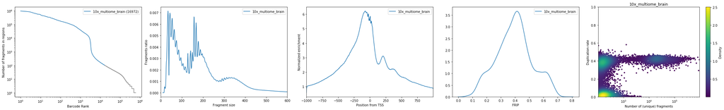

```python
from pycisTopic.qc import *
plot_sample_metrics(profile_data_dict,
           insert_size_distriubtion_xlim=[0,600],
           ncol=5,
           plot=True,
           save='/staging/leuven/stg_00002/lcb/cbravo/Multiomics_pipeline/analysis/10x_multiome_brain/output/atac/pycistopic/quality_control/sample_metrics.pdf')
```

[Back to top]

#### 3b. Barcode level statistics

Barcode-level statistics can be used to select high quality cells. Typical measurements that can be used are:

- **Total number of (unique) fragments**
- **TSS enrichment**: The score at position in the TSS enrichmen score for for each barcode (at position 0, the TSS). Noisy cells will have a low TSS enrichment.
- **FRIP**: The fraction of reads in peaks for each barcode. Noisy cells have low FRIP values. However, this filter should be used with nuance, as it depends on the quality of the original peaks. For example, if there is a rare population in the sample, its specific peaks may be missed by peak calling algorithms, causing a decrease in their FRIP values.

```python
# Load barcode metrics
import pickle
infile = open('/staging/leuven/stg_00002/lcb/cbravo/Multiomics_pipeline/analysis/10x_multiome_brain/output/atac/pycistopic/quality_control/metadata_bc.pkl', 'rb')
metadata_bc = pickle.load(infile)
infile.close()
```

```python
# Return figure to plot together with other metrics, and cells passing filters. Figure will be saved as pdf.
from pycisTopic.qc import *
FRIP_NR_FRAG_fig, FRIP_NR_FRAG_filter=plot_barcode_metrics(metadata_bc['10x_multiome_brain'],
                                       var_x='Log_unique_nr_frag',
                                       var_y='FRIP',
                                       min_x=3.5,
                                       max_x=None,
                                       min_y=0.2,
                                       max_y=None,
                                       return_cells=True,
                                       return_fig=True,
                                       plot=False,
                                       save='/staging/leuven/stg_00002/lcb/cbravo/Multiomics_pipeline/analysis/10x_multiome_brain/output/atac/pycistopic/quality_control/barcode_metrics/FRIP-VS-NRFRAG.pdf')
# Return figure to plot together with other metrics, and cells passing filters
TSS_NR_FRAG_fig, TSS_NR_FRAG_filter=plot_barcode_metrics(metadata_bc['10x_multiome_brain'],
                                      var_x='Log_unique_nr_frag',
                                      var_y='TSS_enrichment',
                                      min_x=3.5,
                                      max_x=None,
                                      min_y=4,
                                      max_y=None,
                                      return_cells=True,
                                      return_fig=True,
                                      plot=False,
                                      save='/staging/leuven/stg_00002/lcb/cbravo/Multiomics_pipeline/analysis/10x_multiome_brain/output/atac/pycistopic/quality_control/barcode_metrics/TSS-VS-NRFRAG.pdf')
# Return figure to plot together with other metrics, but not returning cells (no filter applied for the duplication rate  per barcode)
DR_NR_FRAG_fig=plot_barcode_metrics(metadata_bc['10x_multiome_brain'],
                                      var_x='Log_unique_nr_frag',
                                      var_y='Dupl_rate',
                                      min_x=3.5,
                                      max_x=None,
                                      min_y=None,
                                      max_y=None,
                                      return_cells=False,
                                      return_fig=True,
                                      plot=False)
```

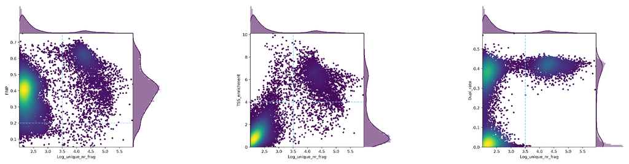

```python
# Plot barcode stats in one figure
fig=plt.figure(figsize=(40,10))
plt.subplot(1, 3, 1)
img = fig2img(FRIP_NR_FRAG_fig) #To convert figures to png to plot together, see .utils.py. This converts the figure to png.
plt.imshow(img)
plt.axis('off')
plt.subplot(1, 3, 2)
img = fig2img(TSS_NR_FRAG_fig)
plt.imshow(img)
plt.axis('off')
plt.subplot(1, 3, 3)
img = fig2img(DR_NR_FRAG_fig)
plt.imshow(img)
plt.axis('off')
plt.show()
```

```python
# Remove cells marked as doublets in the scRNA-seq analysis
from loomxpy import SCopeLoom
from pycisTopic.loom import *
path_to_annotated_rna_loom = "/staging/leuven/stg_00002/lcb/cbravo/Multiomics_pipeline/analysis/10x_multiome_brain/output/rna/vsn/add_clusters_scrublet_as_annot/10x_multiome_brain_SCENIC_SCope_output-wAnnot-wDBL.loom"
loom = SCopeLoom.read_loom(path_to_annotated_rna_loom)
cell_data = get_metadata(loom)
# Here I apply a corection to get the correct barcode name
SCRUBLET_doublets = [re.sub("-1.0.0", "-1", x) for x in cell_data[cell_data['scrublet__predicted_doublets'] == 1].index.tolist()]
```

```python
bc_passing_filters = {'10x_multiome_brain':[]}
bc_passing_filters['10x_multiome_brain'] = list((set(FRIP_NR_FRAG_filter) & set(TSS_NR_FRAG_filter)) ^ set(SCRUBLET_doublets))
```

We have a total of 2,916 selected barcodes.

```python
len(bc_passing_filters['10x_multiome_brain'])
```

```
2916
```

Of these, a total of 2,233 overlaps with high quality scRNA-seq barcodes. We will keep the additional barcodes for now.

```python
# Get metadata from high-quality loom file
from pycisTopic.loom import *
path_to_annotated_rna_loom = "/staging/leuven/stg_00002/lcb/cbravo/Multiomics_pipeline/analysis/10x_multiome_brain/output/rna/vsn/add_clusters_scrublet_as_annot/10x_multiome_brain_SCENIC_SCope_output_wAnnot_noDBL.loom"
loom = SCopeLoom.read_loom(path_to_annotated_rna_loom)
cell_data = get_metadata(loom)
scRNA_bc=[re.sub("-10x_multiome_brain", "", x) for x in cell_data.index.tolist()]
#len(scRNA_bc) 2,607 cells
len(list(set(bc_passing_filters['10x_multiome_brain']) & set(scRNA_bc)))
```

```
2233
```

```python
import pickle
with open('/staging/leuven/stg_00002/lcb/cbravo/Multiomics_pipeline/analysis/10x_multiome_brain/output/atac/pycistopic/quality_control/bc_passing_filters.pkl', 'wb') as f:
  pickle.dump(bc_passing_filters, f)
```

[Back to top]

### 4. Creating a cisTopic object

In this step a fragments count matrix will be generated, in which the fragments in each region for each barcode is indicated. If you would like to start from a precomputed fragments count matrix it is also possible (see advanced tutorial on *Initializing cisTopic objects*). For multiple samples, you can add additional entries in `fragment_dict`. As regions, we will use the consensus peaks derived from the scRNA-seq annotations. This cisTopic object will contain:

- Path/s to fragment file/s (if generated from fragments files)
- Fragment count matrix and binary accessibility matrix
- Cell and region metadata

```python
# Path to fragments
fragments_dict = {'10x_multiome_brain':'/staging/leuven/stg_00002/lcb/cbravo/Multiomics_pipeline/analysis/10x_multiome_brain/data/cell-arc/1.0.0/outs/human_brain_3k_atac_fragments.tsv.gz'}
# Path to regions
path_to_regions = '/staging/leuven/stg_00002/lcb/cbravo/Multiomics_pipeline/analysis/10x_multiome_brain/output/atac/pycistopic/consensus_peak_calling/consensus_regions.bed'
# Blacklist
path_to_blacklist='/staging/leuven/stg_00002/lcb/cbravo/Multiomics_pipeline/pycisTopic/blacklist/hg38-blacklist.v2.bed'
# Metrics
import pickle
infile = open('/staging/leuven/stg_00002/lcb/cbravo/Multiomics_pipeline/analysis/10x_multiome_brain/output/atac/pycistopic/quality_control/metadata_bc.pkl', 'rb')
metadata_bc = pickle.load(infile)
infile.close()
# Valid barcodes
import pickle
infile = open('/staging/leuven/stg_00002/lcb/cbravo/Multiomics_pipeline/analysis/10x_multiome_brain/output/atac/pycistopic/quality_control/bc_passing_filters.pkl', 'rb')
bc_passing_filters = pickle.load(infile)
infile.close()
#Create objects
cistopic_obj_list=[create_cistopic_object_from_fragments(path_to_fragments=fragments_dict[key],
                                               path_to_regions=path_to_regions,
                                               path_to_blacklist=path_to_blacklist,
                                               metrics=metadata_bc[key],
                                               valid_bc=bc_passing_filters[key],
                                               n_cpu=5,
                                               project=key) for key in fragments_dict.keys()]
```

```
2021-03-09 15:23:06,767 cisTopic     INFO     Reading data for 10x_multiome_brain
2021-03-09 15:25:38,487 cisTopic     INFO     metrics provided!
2021-03-09 15:25:57,342 cisTopic     INFO     valid_bc provided, selecting barcodes!
2021-03-09 15:26:15,626 cisTopic     INFO     Counting fragments in regions
```

```
2021-03-09 15:26:15,642	INFO resource_spec.py:212 -- Starting Ray with 161.38 GiB memory available for workers and up to 73.16 GiB for objects. You can adjust these settings with ray.init(memory=<bytes>, object_store_memory=<bytes>).
2021-03-09 15:26:16,187	WARNING services.py:923 -- Redis failed to start, retrying now.
2021-03-09 15:26:18,908	INFO services.py:1165 -- View the Ray dashboard at localhost:8265
```

```
2021-03-09 15:26:53,522 cisTopic     INFO     Creating fragment matrix
2021-03-09 15:28:25,231 cisTopic     INFO     Converting fragment matrix to sparse matrix
2021-03-09 15:28:44,185 cisTopic     INFO     Removing blacklisted regions
2021-03-09 15:28:46,103 cisTopic     INFO     Creating CistopicObject
2021-03-09 15:28:49,969 cisTopic     INFO     Done!
```

In this case we only have one sample, so only one cisTopic object has been generated. If you would have multiple samples, you would need to run the `merge()` function in your cisTopic object list. You can find more information in the advanced tutorial on *Initializing cisTopic objects*.

```python
cistopic_obj = cistopic_obj_list[0]
print(cistopic_obj)
```

```
CistopicObject from project 10x_multiome_brain with n_cells × n_regions = 2916 × 435824
```

```python
# Save
with open('/staging/leuven/stg_00002/lcb/cbravo/Multiomics_pipeline/analysis/10x_multiome_brain/output/atac/pycistopic/10x_multiome_brain_cisTopicObject.pkl', 'wb') as f:
  pickle.dump(cistopic_obj, f)
```

[Back to top]

### 5. Adding metadata to a cisTopic object

We can add additional metadata (for regions or cells) to a cisTopic object. For example, let's add the scRNA-seq data annotations. For those barcodes that did not pass the scRNA-seq values will be filled with `Nan`.

```python
# Load cisTopic object
import pickle
infile = open('/staging/leuven/stg_00002/lcb/cbravo/Multiomics_pipeline/analysis/10x_multiome_brain/output/atac/pycistopic/10x_multiome_brain_cisTopicObject.pkl', 'rb')
cistopic_obj = pickle.load(infile)
infile.close()
```

```python
# Get metadata from loom file
from pycisTopic.loom import *
path_to_annotated_rna_loom = "/staging/leuven/stg_00002/lcb/cbravo/Multiomics_pipeline/analysis/10x_multiome_brain/output/rna/vsn/add_clusters_scrublet_as_annot/10x_multiome_brain_SCENIC_SCope_output_wAnnot_noDBL.loom"
loom = SCopeLoom.read_loom(path_to_annotated_rna_loom)
cell_data = get_metadata(loom).drop('sample_id', axis=1)
```

The indexes in the pandas data frame to add can be **cell barcodes** (if the cisTopic object has been created from a fragments file only) or an **exact match with the cell names** in the cisTopic object (`cistopic_obj.cell_names`).

```python
cistopic_obj.add_cell_data(cell_data)
```

```python
cistopic_obj.cell_data
```

|  | Unique_nr_frag | barcode | cisTopic_log_nr_acc | Unique_nr_frag_in_regions | Dupl_rate | Doublet_scores_fragments | Total_nr_frag_in_regions | TSS_enrichment | cisTopic_nr_acc | sample_id | ... | Log_unique_nr_frag | Total_nr_frag | Dupl_nr_frag | Log_total_nr_frag | cisTopic_log_nr_frag | leiden_res0.9 | leiden_res0.3 | leiden_res1.2 | leiden_res0.6 | cell_type |
| --- | --- | --- | --- | --- | --- | --- | --- | --- | --- | --- | --- | --- | --- | --- | --- | --- | --- | --- | --- | --- | --- |
| AAACAGCCATAGACTT-1-10x_multiome_brain | 16375 | AAACAGCCATAGACTT-1 | 4.001301 | 10708 | 0.432586 | 0.247387 | 19356 | 6.006416 | 10030 | 10x_multiome_brain | ... | 4.214181 | 28859 | 12484 | 4.460281 | 4.060849 | NaN | NaN | NaN | NaN | NaN |
| AAACCAACATAGACCC-1-10x_multiome_brain | 18096 | AAACCAACATAGACCC-1 | 4.015946 | 10866 | 0.418677 | 0.214953 | 19199 | 6.312668 | 10374 | 10x_multiome_brain | ... | 4.257583 | 31129 | 13033 | 4.493165 | 4.063896 | MOL_3 (5) | MOL (0) | MOL_4 (4) | MOL_1 (0) | MOL |
| AAACCGAAGATGCCTG-1-10x_multiome_brain | 52618 | AAACCGAAGATGCCTG-1 | 4.244054 | 19137 | 0.409728 | 0.033684 | 33190 | 4.313557 | 17541 | 10x_multiome_brain | ... | 4.721134 | 89142 | 36524 | 4.950082 | 4.302893 | INH_VIP (8) | INH_VIP (6) | INH_VIP (10) | INH_VIP (8) | INH_VIP |
| AAACCGAAGTTAGCTA-1-10x_multiome_brain | 30037 | AAACCGAAGTTAGCTA-1 | 4.170614 | 16352 | 0.426676 | 0.201183 | 29530 | 5.795824 | 14812 | 10x_multiome_brain | ... | 4.477657 | 52391 | 22354 | 4.719257 | 4.241173 | NFOL_1 (0) | NFOL (1) | NFOL_2 (0) | NFOL_2 (1) | NFOL |
| AAACCGCGTCTTACTA-1-10x_multiome_brain | 30725 | AAACCGCGTCTTACTA-1 | 4.228323 | 18821 | 0.437539 | 0.247387 | 34597 | 6.543591 | 16917 | 10x_multiome_brain | ... | 4.487492 | 54626 | 23901 | 4.737399 | 4.303326 | MOL_1 (1) | MOL (0) | MOL_2 (2) | MOL_2 (3) | MOL |
| ... | ... | ... | ... | ... | ... | ... | ... | ... | ... | ... | ... | ... | ... | ... | ... | ... | ... | ... | ... | ... | ... |
| TTTGTGGCAAGGAATC-1-10x_multiome_brain | 69358 | TTTGTGGCAAGGAATC-1 | 4.521125 | 41032 | 0.431613 | 0.230263 | 75264 | 6.714550 | 33199 | 10x_multiome_brain | ... | 4.841097 | 122026 | 52668 | 5.086452 | 4.63743 | NaN | NaN | NaN | NaN | NaN |
| TTTGTGGCATGCTTAG-1-10x_multiome_brain | 20144 | TTTGTGGCATGCTTAG-1 | 4.065057 | 12671 | 0.432979 | 0.214953 | 23031 | 7.625290 | 11616 | 10x_multiome_brain | ... | 4.304146 | 35526 | 15382 | 4.550546 | 4.131458 | MOL_1 (1) | MOL (0) | MOL_1 (1) | MOL_1 (0) | MOL |
| TTTGTGTTCGTTACAA-1-10x_multiome_brain | 94201 | TTTGTGTTCGTTACAA-1 | 4.507829 | 38731 | 0.420726 | 0.140909 | 70303 | 5.386427 | 32198 | 10x_multiome_brain | ... | 4.974056 | 162619 | 68418 | 5.211171 | 4.610298 | NaN | NaN | NaN | NaN | NaN |
| TTTGTTGGTGATCAGC-1-10x_multiome_brain | 12652 | TTTGTTGGTGATCAGC-1 | 3.674677 | 4698 | 0.392140 | 0.09839 | 8031 | 5.348761 | 4728 | 10x_multiome_brain | ... | 4.102159 | 20814 | 8162 | 4.318356 | 3.702431 | NFOL_1 (0) | NFOL (1) | NFOL_1 (11) | NFOL_2 (1) | NFOL |
| TTTGTTGGTGATTTGG-1-10x_multiome_brain | 42680 | TTTGTTGGTGATTTGG-1 | 4.206718 | 17611 | 0.409821 | 0.09375 | 31136 | 6.829190 | 16096 | 10x_multiome_brain | ... | 4.630224 | 72317 | 29637 | 4.859240 | 4.265313 | INH_SST (7) | INH_SST (5) | INH_SST (9) | INH_SST (7) | INH_SST |

2916 rows × 23 columns

[Back to top]

### 6. Running scrublet in a cisTopic object

Optionally, you can run also scrublet on the fragment count matrix to infer doublets from the scATAC-seq.

```
Preprocessing...
```

```
Simulating doublets...
Embedding transcriptomes using PCA...
Calculating doublet scores...
Automatically set threshold at doublet score = 0.66
Detected doublet rate = 0.3%
Estimated detectable doublet fraction = 2.7%
Overall doublet rate:
	Expected   = 10.0%
	Estimated  = 10.3%
Elapsed time: 30.7 seconds
Detected doublet rate = 3.3%
Estimated detectable doublet fraction = 28.9%
Overall doublet rate:
	Expected   = 10.0%
	Estimated  = 11.5%
```

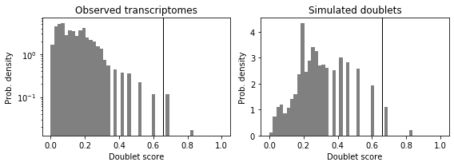

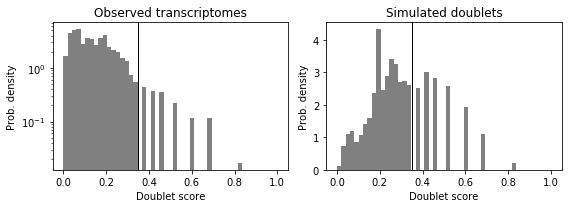

```python
import scrublet as scr
scrub = scr.Scrublet(cistopic_obj.fragment_matrix.T, expected_doublet_rate=0.1)
doublet_scores, predicted_doublets = scrub.scrub_doublets()
scrub.plot_histogram();
scrub.call_doublets(threshold=0.35)
scrub.plot_histogram();
scrublet = pd.DataFrame([scrub.doublet_scores_obs_, scrub.predicted_doublets_], columns=cistopic_obj.cell_names, index=['Doublet_scores_fragments', 'Predicted_doublets_fragments']).T
```

```python
cistopic_obj.add_cell_data(scrublet)
```

```
Columns ['Doublet_scores_fragments', 'Predicted_doublets_fragments'] will be overwritten
```

97 cells are called as doublets.

```python
sum(cistopic_obj.cell_data.Predicted_doublets_fragments == True)
```

```
97
```

```python
# Save with doublets
with open('/staging/leuven/stg_00002/lcb/cbravo/Multiomics_pipeline/analysis/10x_multiome_brain/output/atac/pycistopic/10x_multiome_brain_cisTopicObject.pkl', 'wb') as f:
  pickle.dump(cistopic_obj, f)
```

We can subset all cells marked as singlets from the cisTopic object.

```python
# Remove doublets
singlets = cistopic_obj.cell_data[cistopic_obj.cell_data.Predicted_doublets_fragments == False].index.tolist()
# Subset cisTopic object
cistopic_obj_noDBL = cistopic_obj.subset(singlets, copy=True)
print(cistopic_obj_noDBL)
```

```
CistopicObject from project 10x_multiome_brain with n_cells × n_regions = 2819 × 435824
```

```python
# Save without doublets
with open('/staging/leuven/stg_00002/lcb/cbravo/Multiomics_pipeline/analysis/10x_multiome_brain/output/atac/pycistopic/10x_multiome_brain_cisTopicObject_noDBL.pkl', 'wb') as f:
  pickle.dump(cistopic_obj_noDBL, f)
```

We can also take only cells overlapping with high quality cells in the scRNA-seq. In total, there are 2,199 cells.

```python
# Remove cells without rna counterpart
rna_cells = cistopic_obj_noDBL.cell_data.dropna().index.tolist()
# Subset cisTopic object
cistopic_obj_noDBL_wRNA = cistopic_obj_noDBL.subset(rna_cells, copy=True)
print(cistopic_obj_noDBL_wRNA)
```

```
CistopicObject from project 10x_multiome_brain with n_cells × n_regions = 2199 × 435819
```

```python
# Save without doublets
with open('/staging/leuven/stg_00002/lcb/cbravo/Multiomics_pipeline/analysis/10x_multiome_brain/output/atac/pycistopic/10x_multiome_brain_cisTopicObject_noDBL_wRNA.pkl', 'wb') as f:
  pickle.dump(cistopic_obj_noDBL_wRNA, f)
```

[Back to top]

### 7. Run models

The next step is to run the LDA models. There are two types of LDA models (with Collapsed Gibbs Sampling) you can run:

- **Serial LDA**: The parallelization is done between models rather than within each model. Recommended for small-medium sized data sets in which several models with different number os topics are being tested. You can run these models with `runCGSModels()`.
- **Parallel LDA with MALLET**: The parallelization is done within each model. Recommended for large data sets where a few models with different number of topics are being tested. If working in a cluster, we recommed to submit a job per model so they can run simultaneously. You can run it with `runCGSModelsMallet()`.

In this tutorial we will use `runCGSModels`. For more details in how to run models, see the advanced tutorial on *Running LDA models*.

```python
models=run_cgs_models(cistopic_obj,
                    n_topics=[2,5,10,15,20,25],
                    n_cpu=6,
                    n_iter=100,
                    random_state=555,
                    alpha=50,
                    alpha_by_topic=True,
                    eta=0.1,
                    eta_by_topic=False,
                    save_path=None)
```

```
2021-01-26 17:52:50,478	INFO resource_spec.py:212 -- Starting Ray with 499.37 GiB memory available for workers and up to 186.26 GiB for objects. You can adjust these settings with ray.init(memory=<bytes>, object_store_memory=<bytes>).
2021-01-26 17:52:51,213	WARNING services.py:923 -- Redis failed to start, retrying now.
2021-01-26 17:52:52,152	INFO services.py:1165 -- View the Ray dashboard at localhost:8265
```

```
(pid=779) 2021-01-26 17:53:25,832 cisTopic     INFO     Running model with 2 topics
(pid=784) 2021-01-26 17:53:25,831 cisTopic     INFO     Running model with 10 topics
(pid=783) 2021-01-26 17:53:25,831 cisTopic     INFO     Running model with 15 topics
(pid=780) 2021-01-26 17:53:25,833 cisTopic     INFO     Running model with 5 topics
(pid=782) 2021-01-26 17:53:25,831 cisTopic     INFO     Running model with 20 topics
(pid=785) 2021-01-26 17:53:25,829 cisTopic     INFO     Running model with 25 topics
(pid=779) 2021-01-26 18:05:55,065 cisTopic     INFO     Model with 2 topics done!
(pid=780) 2021-01-26 18:10:09,850 cisTopic     INFO     Model with 5 topics done!
(pid=784) 2021-01-26 18:15:52,994 cisTopic     INFO     Model with 10 topics done!
(pid=783) 2021-01-26 18:21:18,347 cisTopic     INFO     Model with 15 topics done!
(pid=782) 2021-01-26 18:26:05,991 cisTopic     INFO     Model with 20 topics done!
(pid=785) 2021-01-26 18:34:25,387 cisTopic     INFO     Model with 25 topics done!
```

```python
# Save
with open('/staging/leuven/stg_00002/lcb/cbravo/Multiomics_pipeline/analysis/10x_multiome_brain/output/atac/pycistopic/models/10x_multiome_brain_models_100_iter_noDBL_wRNA.pkl', 'wb') as f:
  pickle.dump(models, f)
```

If you are working on a cluster and want to run several models, we recommend to submit this step as a job. You can use the `runModels_lda.py` script.

```python
#!/bin/bash -l
## Job will last 6 hours.
#PBS -l walltime=6:00:00
## Job needs 1 nodes and 24 cores per node.
#PBS -l nodes=1:ppn=28
## Job request memory
#PBS -lmem=180gb # or 180gb
## Specify project credits name to use credits for running the job.
#PBS -A lp_symbiosys
## Batch job name.
#PBS -N 10x_multiomics_brain
## Email options.
#PBS -m abe
#PBS -M carmen.bravogonzalezblas@kuleuven.vib.be

module load Python/3.7.4-foss-2018a
cd /staging/leuven/stg_00002/lcb/cbravo/Multiomics_pipeline/pycisTopic
python job_template/runModels_lda.py \
        -i /staging/leuven/stg_00002/lcb/cbravo/Multiomics_pipeline/analysis/10x_multiome_brain/output/atac/pycistopic/10x_multiome_brain_cisTopicObject_noDBL.pkl \
        -o /staging/leuven/stg_00002/lcb/cbravo/Multiomics_pipeline/analysis/10x_multiome_brain/output/atac/pycistopic/models/10x_multiome_brain_models_500_iter_noDBL.pkl \
        -nt 2,5,10,11,12,13,14,15,16,17,18,19,20,21,22,23,24,25,26,27,28,29,30,35,40,45,50 \
        -c 12 \
        -it 500 \
        -a 50 \
        -abt True \
        -e 0.1 \
        -ebt False \
        -sp None \
        -s 555
```

[Back to top]

### 8. Model selection

There are several methods that can be used for model selection:

- **Minmo_2011**: Uses the average model coherence as calculated by Mimno et al (2011). In order to reduce the impact of the number of topics, we calculate the average coherence based on the top selected average values. The better the model, the higher coherence.
- **Log-likelihood**: Uses the log-likelihood in the last iteration as calculated by Griffiths and Steyvers (2004). The better the model, the higher the log-likelihood.
- **Arun_2010**: Uses a density-based metric as in Arun et al (2010) using the topic-region distribution, the cell-topic distribution and the cell coverage. The better the model, the lower the metric.
- **Cao_Juan_2009**: Uses a divergence-based metric as in Cao Juan et al (2009) using the topic-region distribution. The better the model, the lower the metric.

For scATAC-seq data models, the most helpful methods are Minmo (topic coherence) and the log-likelihood in the last iteration.

```python
# Load cisTopic object
import pickle
infile = open('/staging/leuven/stg_00002/lcb/cbravo/Multiomics_pipeline/analysis/10x_multiome_brain/output/atac/pycistopic/10x_multiome_brain_cisTopicObject_noDBL.pkl', 'rb')
cistopic_obj = pickle.load(infile)
infile.close()
```

```python
# Load models
from pycisTopic.lda_models import *
import pickle
infile = open('/staging/leuven/stg_00002/lcb/cbravo/Multiomics_pipeline/analysis/10x_multiome_brain/output/atac/pycistopic/models/10x_multiome_brain_models_500_iter.pkl', 'rb')
models = pickle.load(infile)
infile.close()
```

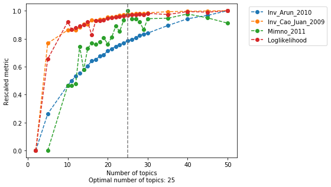

```python
model=evaluate_models(models,
                     select_model=25,
                     return_model=True,
                     metrics=['Arun_2010','Cao_Juan_2009', 'Minmo_2011', 'loglikelihood'],
                     plot_metrics=False,
                     save='/staging/leuven/stg_00002/lcb/cbravo/Multiomics_pipeline/analysis/10x_multiome_brain/output/atac/pycistopic/models/model_selection.pdf')
```

```python
# Load cisTopic object
import pickle
infile = open('/staging/leuven/stg_00002/lcb/cbravo/Multiomics_pipeline/analysis/10x_multiome_brain/output/atac/pycistopic/10x_multiome_brain_cisTopicObject_noDBL.pkl', 'rb')
cistopic_obj = pickle.load(infile)
infile.close()
# Add model to cisTopicObject
cistopic_obj.add_LDA_model(model)
```

```python
# Save
with open('/staging/leuven/stg_00002/lcb/cbravo/Multiomics_pipeline/analysis/10x_multiome_brain/output/atac/pycistopic/10x_multiome_brain_cisTopicObject_noDBL.pkl', 'wb') as f:
  pickle.dump(cistopic_obj, f)
```

[Back to top]

### 9. Clustering and visualization

We can cluster the cells (or regions) using the leiden algorithm, and perfor dimensionality reductiion with UMAP and TSNE. In these examples we will focus on the cells only. For these steps, the cell-topic contriibutions of the model will be used.

```python
# Load cisTopic object
import pickle
infile = open('/staging/leuven/stg_00002/lcb/cbravo/Multiomics_pipeline/analysis/10x_multiome_brain/output/atac/pycistopic/10x_multiome_brain_cisTopicObject_noDBL.pkl', 'rb')
cistopic_obj = pickle.load(infile)
infile.close()
```

```python
from pycisTopic.clust_vis import *
find_clusters(cistopic_obj,
                 target  = 'cell',
                 k = 10,
                 res = 0.6,
                 prefix = 'pycisTopic_')
```

```
2021-03-16 20:36:15,914 cisTopic     INFO     Finding neighbours
2021-03-16 20:36:16,029 cisTopic     INFO     Finding clusters
Columns ['pycisTopic_leiden_10_0.6'] will be overwritten
```

```python
run_umap(cistopic_obj,
                 target  = 'cell')
```

```
2021-03-16 20:36:23,791 cisTopic     INFO     Running UMAP
```

```python
run_tsne(cistopic_obj,
                 target  = 'cell')
```

```
2021-03-16 13:36:27,900 cisTopic     INFO     Running FItSNE
```

The clustering assignments are added to `cistopic_obj.cell_data` and the projections to `cistopic_obj.projections['cell']`. If you would like to add additional dimensionality reductions, you can just add them as an entry to the projections dictionary (under 'cell' in this case).

```python
cistopic_obj.cell_data
```

|  | Unique_nr_frag | barcode | cell_type | cisTopic_log_nr_acc | Dupl_rate | TSS_enrichment | cisTopic_nr_acc | sample_id | cisTopic_nr_frag | Log_unique_nr_frag | ... | Unique_nr_frag_in_regions | leiden_res0.3 | leiden_res1.2 | Total_nr_frag_in_regions | FRIP | Total_nr_frag | Log_total_nr_frag | Doublet_scores_fragments | Predicted_doublets_fragments | pycisTopic_leiden_10_0.6 |
| --- | --- | --- | --- | --- | --- | --- | --- | --- | --- | --- | --- | --- | --- | --- | --- | --- | --- | --- | --- | --- | --- |
| AAACAGCCATAGACTT-1-10x_multiome_brain | 16375 | AAACAGCCATAGACTT-1 | NaN | 4.001301 | 0.432586 | 6.006416 | 10030 | 10x_multiome_brain | 11504 | 4.214181 | ... | 10708 | NaN | NaN | 19356 | 0.653924 | 28859 | 4.460281 | 0.247387 | False | 0 |
| AAACCAACATAGACCC-1-10x_multiome_brain | 18096 | AAACCAACATAGACCC-1 | MOL | 4.015946 | 0.418677 | 6.312668 | 10374 | 10x_multiome_brain | 11585 | 4.257583 | ... | 10866 | MOL (0) | MOL_4 (4) | 19199 | 0.600464 | 31129 | 4.493165 | 0.214953 | False | 1 |
| AAACCGAAGATGCCTG-1-10x_multiome_brain | 52618 | AAACCGAAGATGCCTG-1 | INH_VIP | 4.244054 | 0.409728 | 4.313557 | 17541 | 10x_multiome_brain | 20086 | 4.721134 | ... | 19137 | INH_VIP (6) | INH_VIP (10) | 33190 | 0.363697 | 89142 | 4.950082 | 0.033684 | False | 9 |
| AAACCGAAGTTAGCTA-1-10x_multiome_brain | 30037 | AAACCGAAGTTAGCTA-1 | NFOL | 4.170614 | 0.426676 | 5.795824 | 14812 | 10x_multiome_brain | 17425 | 4.477657 | ... | 16352 | NFOL (1) | NFOL_2 (0) | 29530 | 0.544395 | 52391 | 4.719257 | 0.201183 | False | 1 |
| AAACCGCGTCTTACTA-1-10x_multiome_brain | 30725 | AAACCGCGTCTTACTA-1 | MOL | 4.228323 | 0.437539 | 6.543591 | 16917 | 10x_multiome_brain | 20106 | 4.487492 | ... | 18821 | MOL (0) | MOL_2 (2) | 34597 | 0.612563 | 54626 | 4.737399 | 0.247387 | False | 1 |
| ... | ... | ... | ... | ... | ... | ... | ... | ... | ... | ... | ... | ... | ... | ... | ... | ... | ... | ... | ... | ... | ... |
| TTTGTGGCAAGGAATC-1-10x_multiome_brain | 69358 | TTTGTGGCAAGGAATC-1 | NaN | 4.521125 | 0.431613 | 6.714550 | 33199 | 10x_multiome_brain | 43394 | 4.841097 | ... | 41032 | NaN | NaN | 75264 | 0.591597 | 122026 | 5.086452 | 0.230263 | False | 7 |
| TTTGTGGCATGCTTAG-1-10x_multiome_brain | 20144 | TTTGTGGCATGCTTAG-1 | MOL | 4.065057 | 0.432979 | 7.625290 | 11616 | 10x_multiome_brain | 13535 | 4.304146 | ... | 12671 | MOL (0) | MOL_1 (1) | 23031 | 0.629021 | 35526 | 4.550546 | 0.214953 | False | 0 |
| TTTGTGTTCGTTACAA-1-10x_multiome_brain | 94201 | TTTGTGTTCGTTACAA-1 | NaN | 4.507829 | 0.420726 | 5.386427 | 32198 | 10x_multiome_brain | 40766 | 4.974056 | ... | 38731 | NaN | NaN | 70303 | 0.411153 | 162619 | 5.211171 | 0.140909 | False | 7 |
| TTTGTTGGTGATCAGC-1-10x_multiome_brain | 12652 | TTTGTTGGTGATCAGC-1 | NFOL | 3.674677 | 0.392140 | 5.348761 | 4728 | 10x_multiome_brain | 5040 | 4.102159 | ... | 4698 | NFOL (1) | NFOL_1 (11) | 8031 | 0.371325 | 20814 | 4.318356 | 0.09839 | False | 3 |
| TTTGTTGGTGATTTGG-1-10x_multiome_brain | 42680 | TTTGTTGGTGATTTGG-1 | INH_SST | 4.206718 | 0.409821 | 6.829190 | 16096 | 10x_multiome_brain | 18421 | 4.630224 | ... | 17611 | INH_SST (5) | INH_SST (9) | 31136 | 0.412629 | 72317 | 4.859240 | 0.09375 | False | 6 |

2819 rows × 24 columns

We can also visualize metadata (categorical or continuous) on the UMAP/tSNE spaces.

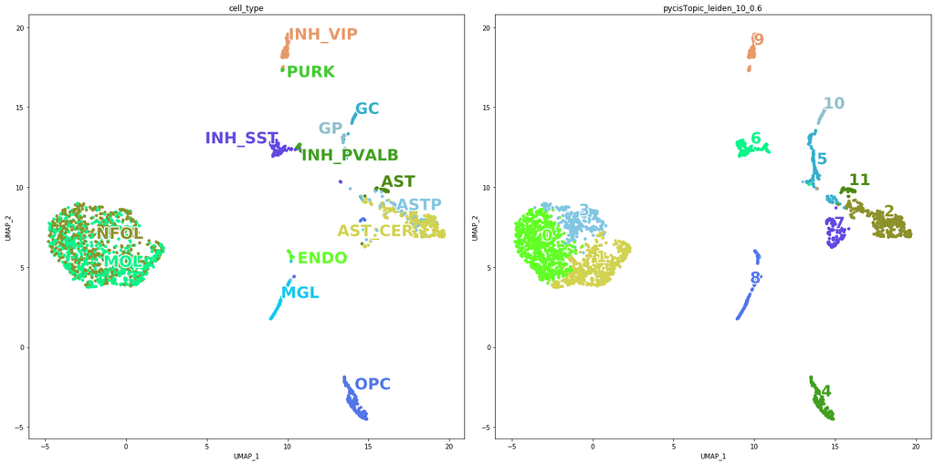

```python
plot_metadata(cistopic_obj,
                 reduction_name='UMAP',
                 variables=['cell_type', 'pycisTopic_leiden_10_0.6'], # Labels from RNA and new clusters
                 target='cell', num_columns=2,
                 text_size=24,
                 dot_size=15,
                 figsize=(20,10),
                 save='/staging/leuven/stg_00002/lcb/cbravo/Multiomics_pipeline/analysis/10x_multiome_brain/output/atac/pycistopic/visualization/dimensionality_reduction_label.pdf')
```

We can also check other statistics. For example, here we see that many of the non-matching cells with the RNA profiles have a high number of fragments and high doublet scores.

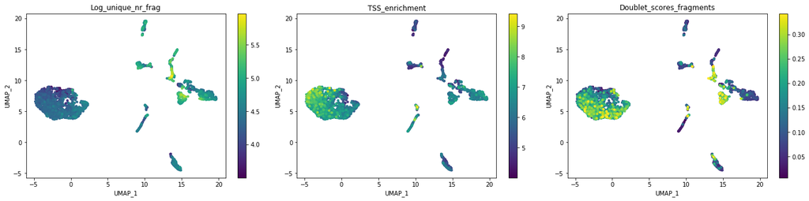

```python
plot_metadata(cistopic_obj,
                 reduction_name='UMAP',
                 variables=['Log_unique_nr_frag', 'TSS_enrichment', 'Doublet_scores_fragments'],
                 target='cell', num_columns=3,
                 text_size=15,
                 save='/staging/leuven/stg_00002/lcb/cbravo/Multiomics_pipeline/analysis/10x_multiome_brain/output/atac/pycistopic/visualization/dimensionality_reduction_number.pdf')
```

We can also plot the topic-contributions.

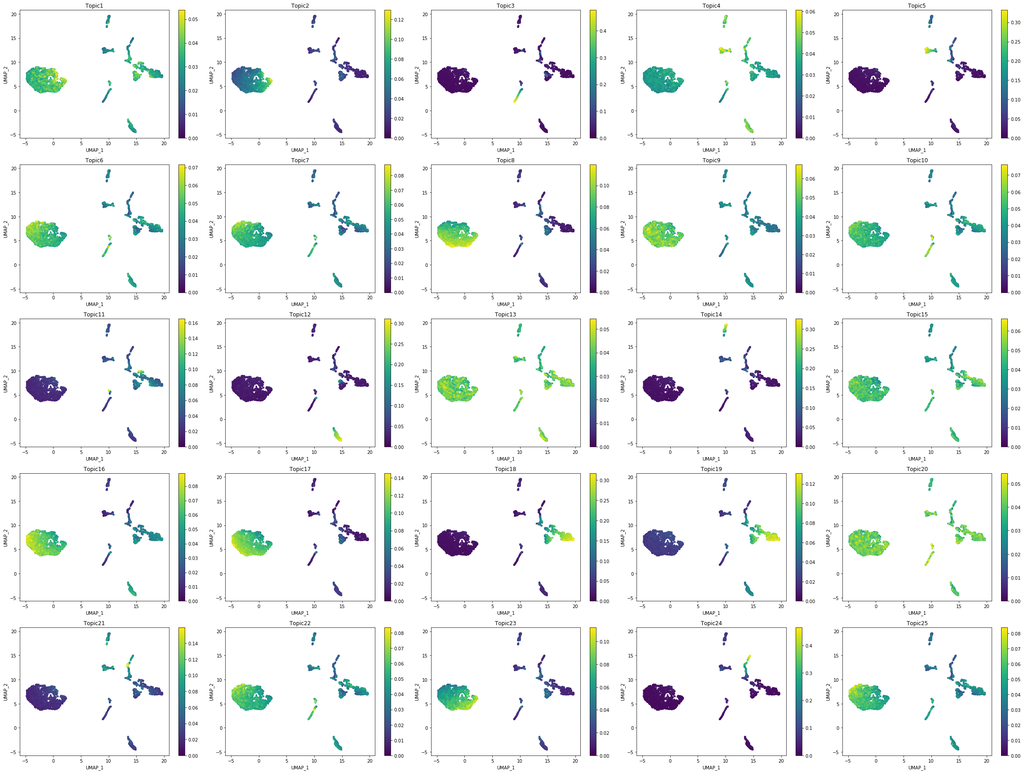

```python
plot_topic(cistopic_obj,
            reduction_name = 'UMAP',
            target = 'cell',
            num_columns=5,
            save='/staging/leuven/stg_00002/lcb/cbravo/Multiomics_pipeline/analysis/10x_multiome_brain/output/atac/pycistopic/visualization/dimensionality_reduction_topic_contr.pdf')
```

Or we can also draw a heatmap with the topic contributions (and annotations).

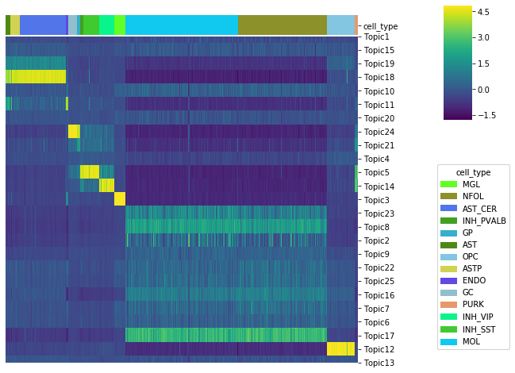

```python
cell_topic_heatmap(cistopic_obj,
                     variables = ['cell_type'],
                     scale = True,
                     legend_loc_x = 1.05,
                     legend_loc_y = -1.2,
                     legend_dist_y = -1,
                     figsize=(10,10),
                     save = '/staging/leuven/stg_00002/lcb/cbravo/Multiomics_pipeline/analysis/10x_multiome_brain/output/atac/pycistopic/visualization/heatmap_topic_contr.pdf')
```

```python
# Save
with open('/staging/leuven/stg_00002/lcb/cbravo/Multiomics_pipeline/analysis/10x_multiome_brain/output/atac/pycistopic/10x_multiome_brain_cisTopicObject_noDBL.pkl', 'wb') as f:
  pickle.dump(cistopic_obj, f)
```

[Back to top]

### 10. Topic binarization & qc

Next we can binarize topic-region and cell-topic distributions. The first is useful for exploring the topics with other tools that work with region sets (e.g. GREAT, cisTarget); while the latter is useful to automatically automate topics.

```python
# Load cisTopic object
import pickle
infile = open('/staging/leuven/stg_00002/lcb/cbravo/Multiomics_pipeline/analysis/10x_multiome_brain/output/atac/pycistopic/10x_multiome_brain_cisTopicObject_noDBL.pkl', 'rb')
cistopic_obj = pickle.load(infile)
infile.close()
```

We will first binarize the topic-region distributions. There are several methods that can be used for this: 'otsu' (Otsu, 1979), 'yen' (Yen et al., 1995), 'li' (Li & Lee, 1993), 'aucell' (Van de Sande et al., 2020) or 'ntop' (Taking the top n regions per topic). Otsu and Yen's methods work well in topic-region distributions; however for some downstream analyses it may be convenient to use 'ntop' to have balanced region sets.

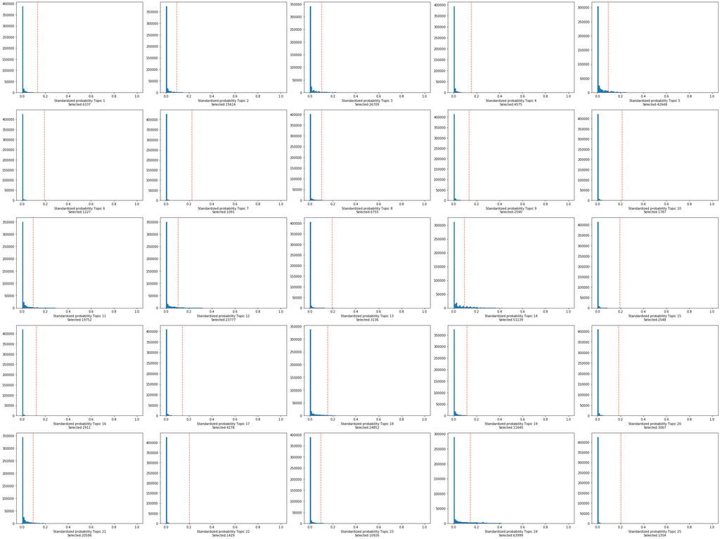

```python
from pycisTopic.topic_binarization import *
region_bin_topics = binarize_topics(cistopic_obj, method='otsu', ntop=3000, plot=True, num_columns=5, save='/staging/leuven/stg_00002/lcb/cbravo/Multiomics_pipeline/analysis/10x_multiome_brain/output/atac/pycistopic/topic_binarization/otsu.pdf')
```

We can see that some thresholds may be a bit off for example topic 24 contains 64K regions. We can manually adjust some of these thresholds using the predefined_thr parameter.

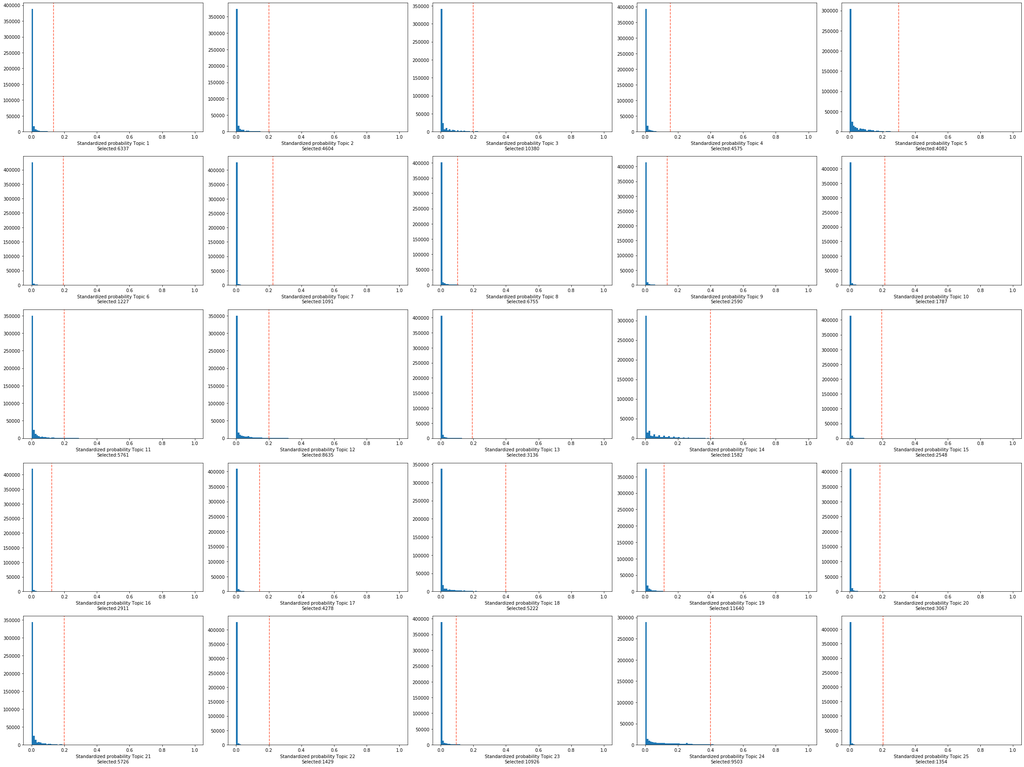

```python
predifined_thr={'Topic2':0.2, 'Topic3':0.2, 'Topic5':0.3, 'Topic11':0.2, 'Topic12':0.2, 'Topic14':0.4, 'Topic18':0.4, 'Topic21':0.2, 'Topic24':0.4}
region_bin_topics = binarize_topics(cistopic_obj, method='otsu', ntop=3000, plot=True, num_columns=5, predifined_thr=predifined_thr, save='/staging/leuven/stg_00002/lcb/cbravo/Multiomics_pipeline/analysis/10x_multiome_brain/output/atac/pycistopic/topic_binarization/otsu.pdf')
```

Similarly, we can now binarize the cell-topic distribions.

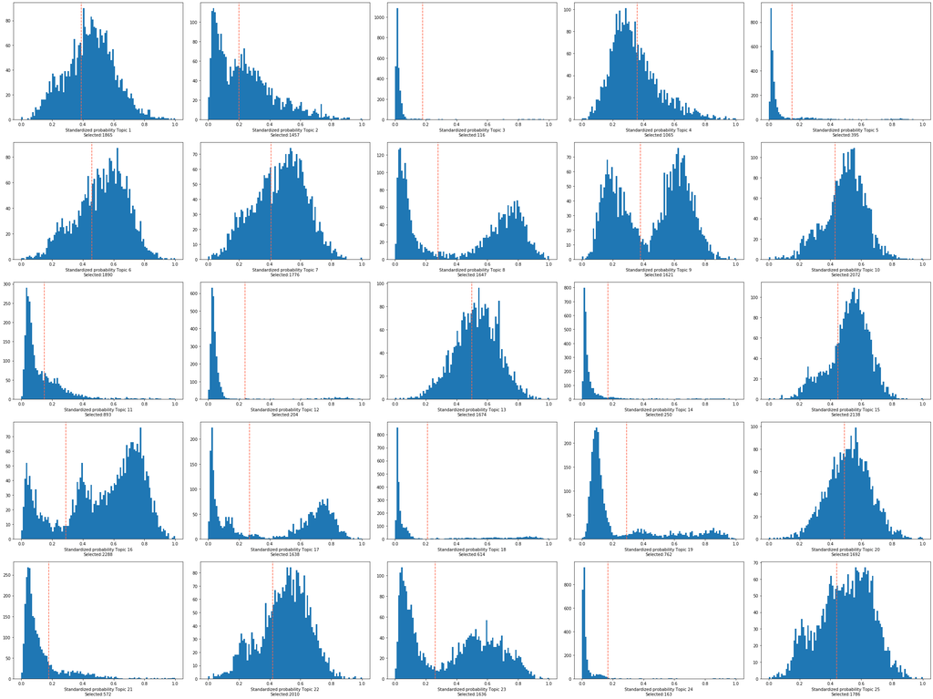

```python
binarized_cell_topic = binarize_topics(cistopic_obj, target='cell', method='li', plot=True, num_columns=5, nbins=100)
```

As in the topic-region distributions we see that some thresholds are not very accurate. We can adjust the manually.

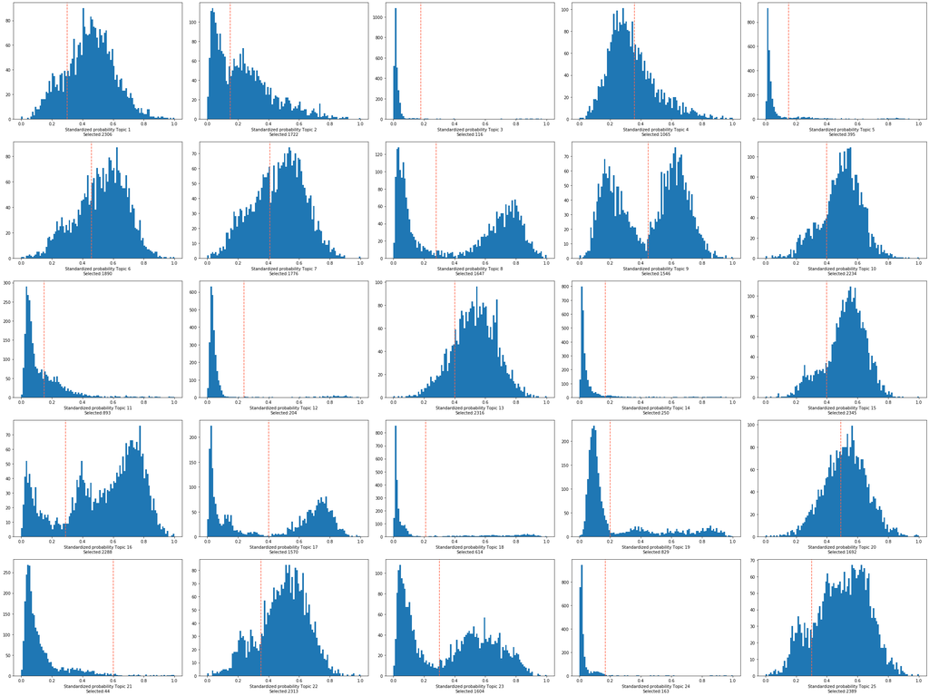

```python
predifined_thr={'Topic1':0.3, 'Topic2':0.15, 'Topic9':0.45, 'Topic10':0.4, 'Topic13':0.4, 'Topic15':0.4,  'Topic17':0.4, 'Topic19':0.2, 'Topic21':0.6, 'Topic22':0.35, 'Topic23':0.3, 'Topic25':0.3}
binarized_cell_topic = binarize_topics(cistopic_obj, target='cell', method='li', plot=True, num_columns=5, nbins=100, predifined_thr=predifined_thr)
```

Following, we can compute the topic quality control metrics. These include:

- **Number of assignments**
- **Topic coherence (Mimno et al., 2011)**: Measures to which extent high scoring regions in the topic are actually co-accessible in the original data. If it is low it indicates that the topic is rather random. The higher, the better is a topic.
- **The marginal topic distribution**: Indicates how much each topic contributes to the model. The higher, the better is a topic.
- **The gini index**: Value between 0 and 1, that indicates the specificity of topics (0: General, 1:Specific)
- If topics have been binarized, the number of regions/cells per topic will be added.

```python
from pycisTopic.topic_qc import *
topic_qc_metrics = compute_topic_metrics(cistopic_obj)
```

We will create a figure dictionary to put all plots together. In this case, we will not put any threshold to filter topics.

```python
fig_dict={}
fig_dict['CoherenceVSAssignments']=plot_topic_qc(topic_qc_metrics, var_x='Coherence', var_y='Log10_Assignments', var_color='Gini_index', plot=False, return_fig=True)
fig_dict['AssignmentsVSCells_in_bin']=plot_topic_qc(topic_qc_metrics, var_x='Log10_Assignments', var_y='Cells_in_binarized_topic', var_color='Gini_index', plot=False, return_fig=True)
fig_dict['CoherenceVSCells_in_bin']=plot_topic_qc(topic_qc_metrics, var_x='Coherence', var_y='Cells_in_binarized_topic', var_color='Gini_index', plot=False, return_fig=True)
fig_dict['CoherenceVSRegions_in_bin']=plot_topic_qc(topic_qc_metrics, var_x='Coherence', var_y='Regions_in_binarized_topic', var_color='Gini_index', plot=False, return_fig=True)
fig_dict['CoherenceVSMarginal_dist']=plot_topic_qc(topic_qc_metrics, var_x='Coherence', var_y='Marginal_topic_dist', var_color='Gini_index', plot=False, return_fig=True)
fig_dict['CoherenceVSGini_index']=plot_topic_qc(topic_qc_metrics, var_x='Coherence', var_y='Gini_index', var_color='Gini_index', plot=False, return_fig=True)
```

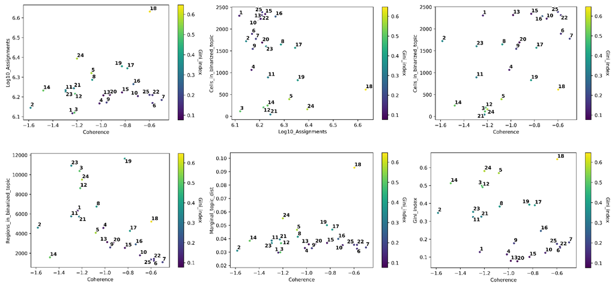

```python
# Plot topic stats in one figure
fig=plt.figure(figsize=(40, 43))
i = 1
for fig_ in fig_dict.keys():
    plt.subplot(2, 3, i)
    img = fig2img(fig_dict[fig_]) #To convert figures to png to plot together, see .utils.py. This converts the figure to png.
    plt.imshow(img)
    plt.axis('off')
    i += 1
plt.subplots_adjust(wspace=0, hspace=-0.70)
fig.savefig('/staging/leuven/stg_00002/lcb/cbravo/Multiomics_pipeline/analysis/10x_multiome_brain/output/atac/pycistopic/topic_binarization/Topic_qc.pdf', bbox_inches='tight')
plt.show()
```

Topic 18 (Astrocytes) is an example of a good topic: it has a high coherence and a high number of assignmnents/marginal topic score (these measurements are correlated), while being cell type specific (with a high gini index). Topic 2 is an example of a bad topic: it has low coherence and a low number of assignments while being general (found in many cells and with and intermediate gini index). In some ocassions, for example topic 14, we observe a low number of assignments and a low coherence, but this can also occur if topics are very specific. Generally, we will consider a topic as bad if it has a low number of assignments while being assigned to many cells and a low coherence.

Next, we can automatically annotate topics, in this case by cell type. Here we calculate the proportion of cells in each group that are assigned to the binarized topic in comparison to the ratio in the whole data set. We will consider a topic as general if the difference between the ration of cells in the whole data set in the binarized topic and the ratio of total cells in the assigned groups is above 0.2. This indicates that the topic is general, and the propotion test may fail if the topic is enriched in both foreground (the group) and background (the whole data set); resulting in a big difference between the ratios.

```python
topic_annot = topic_annotation(cistopic_obj, annot_var='cell_type', binarized_cell_topic=binarized_cell_topic, general_topic_thr = 0.2)
```

```python
topic_annot
```

|  | cell_type | Ratio_cells_in_topic | Ratio_group_in_population | is_general |
| --- | --- | --- | --- | --- |
| Topic1 | NFOL, AST, ASTP, ENDO, MOL | 0.818021 | 0.485278 | True |
| Topic2 | NFOL, MOL | 0.610855 | 0.447322 | False |
| Topic3 | MGL | 0.041149 | 0.023767 | False |
| Topic4 | INH_PVALB, GP, OPC, ENDO, GC, PURK, INH_SST, I... | 0.377794 | 0.17453 | True |
| Topic5 | INH_PVALB, GP, GC, PURK, INH_SST, INH_VIP | 0.140121 | 0.108904 | False |
| Topic6 | NFOL, MGL, MOL | 0.670451 | 0.471089 | False |
| Topic7 | NFOL, MGL, ENDO, MOL | 0.630011 | 0.47641 | False |
| Topic8 | NFOL, MOL | 0.58425 | 0.447322 | False |
| Topic9 | NFOL, MOL | 0.548421 | 0.447322 | False |
| Topic10 | NFOL, MGL, AST_CER, ASTP, ENDO, MOL | 0.79248 | 0.600213 | False |
| Topic11 | INH_PVALB, AST_CER, AST, ASTP, ENDO, PURK, INH... | 0.316779 | 0.222419 | False |
| Topic12 | OPC | 0.072366 | 0.060305 | False |
| Topic13 | NFOL, AST_CER, OPC, MOL | 0.821568 | 0.609436 | True |
| Topic14 | INH_PVALB, PURK, INH_SST, INH_VIP | 0.088684 | 0.082653 | False |
| Topic15 | NFOL, AST_CER, OPC, ASTP, MOL | 0.831855 | 0.63143 | True |
| Topic16 | NFOL, AST_CER, OPC, ASTP, MOL | 0.811635 | 0.63143 | False |
| Topic17 | NFOL, MOL | 0.556935 | 0.447322 | False |
| Topic18 | AST_CER, AST, ASTP | 0.217808 | 0.134445 | False |
| Topic19 | AST_CER, AST, OPC, ASTP, ENDO | 0.294076 | 0.200071 | False |
| Topic20 | MGL, AST_CER, ENDO, MOL | 0.600213 | 0.380631 | True |
| Topic21 | GP, PURK | 0.015608 | 0.014189 | False |
| Topic22 | NFOL, MGL, OPC, ENDO, MOL | 0.820504 | 0.536715 | True |
| Topic23 | NFOL, MOL | 0.568996 | 0.447322 | False |
| Topic24 | GP, GC, INH_SST | 0.057822 | 0.062079 | False |
| Topic25 | NFOL, MGL, AST_CER, AST, OPC, ASTP, MOL | 0.847464 | 0.665839 | False |

We can merge the topic metrics and their annotation in a data frame.

```python
topic_qc_metrics = pd.concat([topic_annot[['cell_type', 'Ratio_cells_in_topic', 'Ratio_group_in_population']], topic_qc_metrics], axis=1)
```

```python
topic_qc_metrics
```

|  | cell_type | Ratio_cells_in_topic | Ratio_group_in_population | Log10_Assignments | Assignments | Regions_in_binarized_topic | Cells_in_binarized_topic | Coherence | Marginal_topic_dist | Gini_index |
| --- | --- | --- | --- | --- | --- | --- | --- | --- | --- | --- |
| Topic1 | NFOL, AST, ASTP, ENDO, MOL | 0.818021 | 0.485278 | 6.117389 | 1310354 | 6337 | 2306 | -1.238522 | 0.029658 | 0.128171 |
| Topic2 | NFOL, MOL | 0.610855 | 0.447322 | 6.145125 | 1396769 | 4604 | 1722 | -1.584480 | 0.031083 | 0.347345 |
| Topic3 | MGL | 0.041149 | 0.023767 | 6.120798 | 1320680 | 10380 | 116 | -1.221333 | 0.029874 | 0.499630 |
| Topic4 | INH_PVALB, GP, OPC, ENDO, GC, PURK, INH_SST, I... | 0.377794 | 0.17453 | 6.167102 | 1469273 | 4575 | 1065 | -1.014104 | 0.033026 | 0.115176 |
| Topic5 | INH_PVALB, GP, GC, PURK, INH_SST, INH_VIP | 0.140121 | 0.108904 | 6.320727 | 2092797 | 4082 | 395 | -1.080604 | 0.046616 | 0.570000 |
| Topic6 | NFOL, MGL, MOL | 0.670451 | 0.471089 | 6.168967 | 1475593 | 1227 | 1890 | -0.574475 | 0.032515 | 0.151943 |
| Topic7 | NFOL, MGL, ENDO, MOL | 0.630011 | 0.47641 | 6.184720 | 1530099 | 1091 | 1776 | -0.499060 | 0.033479 | 0.182438 |
| Topic8 | NFOL, MOL | 0.58425 | 0.447322 | 6.286767 | 1935382 | 6755 | 1647 | -1.073957 | 0.041455 | 0.383144 |
| Topic9 | NFOL, MOL | 0.548421 | 0.447322 | 6.171940 | 1485729 | 2590 | 1546 | -0.955226 | 0.032884 | 0.177230 |
| Topic10 | NFOL, MGL, AST_CER, ASTP, ENDO, MOL | 0.79248 | 0.600213 | 6.204248 | 1600471 | 1787 | 2234 | -0.695808 | 0.035181 | 0.123937 |
| Topic11 | INH_PVALB, AST_CER, AST, ASTP, ENDO, PURK, INH... | 0.316779 | 0.222419 | 6.234390 | 1715498 | 5761 | 893 | -1.294209 | 0.038575 | 0.324469 |
| Topic12 | OPC | 0.072366 | 0.060305 | 6.215925 | 1644089 | 8635 | 204 | -1.215668 | 0.036634 | 0.490935 |
| Topic13 | NFOL, AST_CER, OPC, MOL | 0.821568 | 0.609436 | 6.208104 | 1614747 | 3136 | 2316 | -0.981503 | 0.035825 | 0.079232 |
| Topic14 | INH_PVALB, PURK, INH_SST, INH_VIP | 0.088684 | 0.082653 | 6.232372 | 1707544 | 1582 | 250 | -1.479220 | 0.038421 | 0.513302 |
| Topic15 | NFOL, AST_CER, OPC, ASTP, MOL | 0.831855 | 0.63143 | 6.222894 | 1670682 | 2548 | 2345 | -0.827098 | 0.036836 | 0.100939 |
| Topic16 | NFOL, AST_CER, OPC, ASTP, MOL | 0.811635 | 0.63143 | 6.264864 | 1840195 | 2911 | 2288 | -0.732811 | 0.039862 | 0.246735 |
| Topic17 | NFOL, MOL | 0.556935 | 0.447322 | 6.344787 | 2212011 | 4278 | 1570 | -0.783057 | 0.046778 | 0.389830 |
| Topic18 | AST_CER, AST, ASTP | 0.217808 | 0.134445 | 6.631957 | 4285058 | 5222 | 614 | -0.597279 | 0.092938 | 0.647308 |
| Topic19 | AST_CER, AST, OPC, ASTP, ENDO | 0.294076 | 0.200071 | 6.355179 | 2265577 | 11640 | 829 | -0.828231 | 0.050059 | 0.393205 |
| Topic20 | MGL, AST_CER, ENDO, MOL | 0.600213 | 0.380631 | 6.210566 | 1623925 | 3067 | 1692 | -0.927508 | 0.036029 | 0.076855 |
| Topic21 | GP, PURK | 0.015608 | 0.014189 | 6.244213 | 1754739 | 5726 | 44 | -1.225504 | 0.039478 | 0.326179 |
| Topic22 | NFOL, MGL, OPC, ENDO, MOL | 0.820504 | 0.536715 | 6.209827 | 1621166 | 1429 | 2313 | -0.574752 | 0.035419 | 0.157730 |
| Topic23 | NFOL, MOL | 0.568996 | 0.447322 | 6.226515 | 1684671 | 10926 | 1604 | -1.293450 | 0.036695 | 0.353040 |
| Topic24 | GP, GC, INH_SST | 0.057822 | 0.062079 | 6.394110 | 2478052 | 9503 | 163 | -1.199992 | 0.055209 | 0.581443 |
| Topic25 | NFOL, MGL, AST_CER, AST, OPC, ASTP, MOL | 0.847464 | 0.665839 | 6.210651 | 1624242 | 1354 | 2389 | -0.599657 | 0.035475 | 0.174016 |

```python
# Save
with open('/staging/leuven/stg_00002/lcb/cbravo/Multiomics_pipeline/analysis/10x_multiome_brain/output/atac/pycistopic/topic_binarization/Topic_qc_metrics_annot.pkl', 'wb') as f:
  pickle.dump(topic_qc_metrics, f)
with open('/staging/leuven/stg_00002/lcb/cbravo/Multiomics_pipeline/analysis/10x_multiome_brain/output/atac/pycistopic/topic_binarization/binarized_cell_topic.pkl', 'wb') as f:
  pickle.dump(binarized_cell_topic, f)
with open('/staging/leuven/stg_00002/lcb/cbravo/Multiomics_pipeline/analysis/10x_multiome_brain/output/atac/pycistopic/topic_binarization/binarized_topic_region.pkl', 'wb') as f:
  pickle.dump(region_bin_topics, f)
```

[Back to top]

### 11. Differentially Accessible Regions (DARs)

```python
# Load cisTopic object
import pickle
infile = open('/staging/leuven/stg_00002/lcb/cbravo/Multiomics_pipeline/analysis/10x_multiome_brain/output/atac/pycistopic/10x_multiome_brain_cisTopicObject_noDBL.pkl', 'rb')
cistopic_obj = pickle.load(infile)
infile.close()
```

Together with working with regulatory topics, we can also identify differentially accessible regions (DARs) between cell types. First, we will impute the region accessibility exploting the cell-topic and topic-region probabilities. To shrink very low probability values to 0, we use a scale factor (by default: 10^6).

```python
from pycisTopic.diff_features import *
imputed_acc_obj = impute_accessibility(cistopic_obj, selected_cells=None, selected_regions=None, scale_factor=10**6)
```

```
2021-03-15 18:57:55,098 cisTopic     INFO     Imputing drop-outs
2021-03-15 18:57:55,804 cisTopic     INFO     Removing small values
2021-03-15 18:58:01,230 cisTopic     INFO     Converting to sparse matrix
2021-03-15 18:58:29,566 cisTopic     INFO     Scaling
2021-03-15 18:58:30,442 cisTopic     INFO     Keep non zero rows
2021-03-15 18:58:31,107 cisTopic     INFO     Filter rows with only zeros
2021-03-15 18:58:32,791 cisTopic     INFO     Create CistopicImputedFeatures object
2021-03-15 18:58:32,793 cisTopic     INFO     Done!
```

Next we will log-normalize the imputed data.

```python
normalized_imputed_acc_obj = normalize_scores(imputed_acc_obj, scale_factor=10**4)
```

```
2021-03-15 18:58:44,337 cisTopic     INFO     Normalizing imputed data
2021-03-15 18:59:41,873 cisTopic     INFO     Done!
```

Optionally, we can iddentify highly variable regions. This is not mandatory, but will speed up the hypothesis testing step for identifying DARs.

```
2021-03-15 18:59:49,719 cisTopic     INFO     Calculating mean and variance
2021-03-15 19:00:27,085 numexpr.utils INFO     Note: NumExpr detected 36 cores but "NUMEXPR_MAX_THREADS" not set, so enforcing safe limit of 8.
```

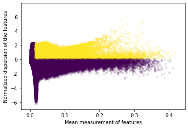

```
2021-03-15 19:01:20,664 cisTopic     INFO     Done!
```

```python
variable_regions = find_highly_variable_features(normalized_imputed_acc_obj,
                                           min_disp = 0.05,
                                           min_mean = 0.0125,
                                           max_mean = 3,
                                           max_disp = np.inf,
                                           n_bins=20,
                                           n_top_features=None,
                                           plot=True,
                                           save='/staging/leuven/stg_00002/lcb/cbravo/Multiomics_pipeline/analysis/10x_multiome_brain/output/atac/pycistopic/DARs/HVR_plot.pdf')
```

There is a total of 69,096 variable features.

```python
len(variable_regions)
```

```
69096
```

We can now identify differentially accessible regions between groups. By default, this function will perform a Wilcoxon rank-sum test between each group in the specified variable and the rest. Alternatively, specified contrast can be provided as a list with foreground and background groups (e.g. for group 1 versus group 2 and 3, and group 2 versus group 1 and 3: [[['Group_1'], ['Group_2, 'Group_3']], [['Group_2'], ['Group_1, 'Group_3']]]).

```python
markers_dict= find_diff_features(cistopic_obj,
                      imputed_acc_obj,
                      variable='cell_type',
                      var_features=variable_regions,
                      contrasts=None,
                      adjpval_thr=0.05,
                      log2fc_thr=np.log2(1.5),
                      n_cpu=5)
```

```
2021-03-15 19:01:33,309	INFO resource_spec.py:212 -- Starting Ray with 479.2 GiB memory available for workers and up to 186.26 GiB for objects. You can adjust these settings with ray.init(memory=<bytes>, object_store_memory=<bytes>).
2021-03-15 19:01:33,741	WARNING services.py:923 -- Redis failed to start, retrying now.
2021-03-15 19:01:35,022	INFO services.py:1165 -- View the Ray dashboard at localhost:8265
```

[output not shown]

[output cut: 286 more lines]

We can also plot region accessibility into the cell-topic UMAP. For example, let's check how the best DARs for AST_CER, OPC, INH_VIP and MGL look like.

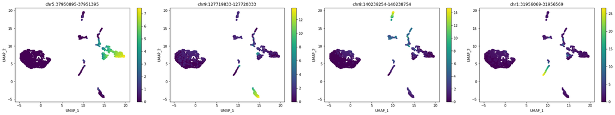

```python
from pycisTopic.clust_vis import *
plot_imputed_features(cistopic_obj,
                    reduction_name='UMAP',
                    imputed_data=imputed_acc_obj,
                    features=[markers_dict[x].index.tolist()[0] for x in ['AST_CER', 'OPC', 'INH_VIP', 'MGL']],
                    scale=False,
                    num_columns=4,
                    save='/staging/leuven/stg_00002/lcb/cbravo/Multiomics_pipeline/analysis/10x_multiome_brain/output/atac/pycistopic/DARs/example_best_DARs.pdf')
```

How many DARs do we find per cell type?

```python
x = [print(x + ': '+ str(len(markers_dict[x]))) for x in markers_dict.keys()]
```

```
AST: 24170
ASTP: 24899
AST_CER: 25606
ENDO: 8391
GC: 11906
GP: 12685
INH_PVALB: 12391
INH_SST: 12250
INH_VIP: 13519
MGL: 9475
MOL: 23540
NFOL: 18726
OPC: 15767
PURK: 15486
```

```python
# Save
with open('/staging/leuven/stg_00002/lcb/cbravo/Multiomics_pipeline/analysis/10x_multiome_brain/output/atac/pycistopic/DARs/Imputed_accessibility.pkl', 'wb') as f:
  pickle.dump(imputed_acc_obj, f)
with open('/staging/leuven/stg_00002/lcb/cbravo/Multiomics_pipeline/analysis/10x_multiome_brain/output/atac/pycistopic/DARs/DARs.pkl', 'wb') as f:
  pickle.dump(markers_dict, f)
```

[Back to top]

### 12. Gene activity

```python
# Load cisTopic object
import pickle
infile = open('/staging/leuven/stg_00002/lcb/cbravo/Multiomics_pipeline/analysis/10x_multiome_brain/output/atac/pycistopic/10x_multiome_brain_cisTopicObject_noDBL.pkl', 'rb')
cistopic_obj = pickle.load(infile)
infile.close()
# Load imputed accessibility
import pickle
infile = open('/staging/leuven/stg_00002/lcb/cbravo/Multiomics_pipeline/analysis/10x_multiome_brain/output/atac/pycistopic/DARs/Imputed_accessibility.pkl', 'rb')
imputed_acc_obj = pickle.load(infile)
infile.close()
# Load DARs
import pickle
infile = open('/staging/leuven/stg_00002/lcb/cbravo/Multiomics_pipeline/analysis/10x_multiome_brain/output/atac/pycistopic/DARs/DARs.pkl', 'rb')
DARs_dict = pickle.load(infile)
infile.close()
```

After imputing region accessibility, we can infer gene accessibility. Next we need to retrieve gene annotation and chromosome sizes for our genome.

```python
# Get TSS annotations
import pybiomart as pbm
import pyranges as pr
# For mouse
#dataset = pbm.Dataset(name='mmusculus_gene_ensembl',  host='http://www.ensembl.org')
# For human
dataset = pbm.Dataset(name='hsapiens_gene_ensembl',  host='http://www.ensembl.org')
# For fly
#dataset = pbm.Dataset(name='dmelanogaster_gene_ensembl',  host='http://www.ensembl.org')
annot = dataset.query(attributes=['chromosome_name', 'start_position', 'end_position', 'strand', 'external_gene_name', 'transcription_start_site', 'transcript_biotype'])
annot['Chromosome/scaffold name'] = 'chr' + annot['Chromosome/scaffold name'].astype(str)
annot.columns=['Chromosome', 'Start', 'End', 'Strand', 'Gene','Transcription_Start_Site', 'Transcript_type']
annot = annot[annot.Transcript_type == 'protein_coding']
annot.Strand[annot.Strand == 1] = '+'
annot.Strand[annot.Strand == -1] = '-'
pr_annotation = pr.PyRanges(annot.dropna(axis = 0))
```

```python
# Get chromosome sizes
import pandas as pd
import requests
target_url='http://hgdownload.cse.ucsc.edu/goldenPath/hg38/bigZips/hg38.chrom.sizes'
chromsizes=pd.read_csv(target_url, sep='\t', header=None)
chromsizes.columns=['Chromosome', 'End']
chromsizes['Start']=[0]*chromsizes.shape[0]
chromsizes=chromsizes.loc[:,['Chromosome', 'Start', 'End']]
chromsizes=pr.PyRanges(chromsizes)
```

Now we can infer gene activity. In this function there are several options to evaluate:

- **Search space**: The user can choose whether the search space should be include other genes or not (`use_gene_boundaries`), and the minimum and maximum distance it should have (`upstream` and `downstream`)
- **Distance weight**: The parameters related to the distance weight measure the impact of distance when inferring region to gene weights as an exponential function. The user can control whether this weight should be used (`distance_weight`) and the effect of the distance (`decay_rate`).
- **Gene size weight**: Large genes may have more peaks by chance. The user can optionally apply a weight based on the size of each gene (`gene_size_weight`), which by default is dividing the size of each gene by the median gene size in the genome. Alternatively, the user can also use `average_scores` which will calculate the gene activity as the mean weighted region accessibility of all regions linked to the gene.
- **Gini weight** : This weight will give more importance to specific regions (`gini_weight`).

In this notebook we select the parameters as indicated below. To speed up calculations, it is also possible to only work with regions in topics or DARs.

```python
from pycisTopic.gene_activity import *
gene_act, weigths = get_gene_activity(imputed_acc_obj, # Region-cell probabilities
                pr_annotation, # Gene annotation
                chromsizes, # Chromosome size
                use_gene_boundaries=True, # Whether to use the whole search space or stop when encountering another gene
                upstream=[1000, 100000], # Search space upstream. The minimum means that even if there is a gene right next to it these bp will be taken (1kbp here)
                downstream=[1000,100000], # Search space downstream
                distance_weight=True, # Whether to add a distance weight (an exponential function, the weight will decrease with distance)
                decay_rate=1, # Exponent for the distance exponential funciton (the higher the faster will be the decrease)
                extend_gene_body_upstream=10000, # Number of bp upstream immune to the distance weight (their value will be maximum for this weight)
                extend_gene_body_downstream=500, # Number of bp downstream immune to the distance weight
                gene_size_weight=False, # Whether to add a weights based on the length of the gene
                gene_size_scale_factor='median', # Dividend to calculate the gene size weigth. Default is the median value of all genes in the genome
                remove_promoters=False, # Whether to remove promoters when computing gene activity scores
                average_scores=True, # Whether to divide by the total number of region assigned to a gene when calculating te gene activity score
                scale_factor=1, # Value to multiply for the final gene activity matrix
                extend_tss=[10,10], # Space to consider a promoter
                gini_weight = True, # Whether to add a gini index weigth. The more unique the region is, the higher this weight will be
                return_weights= True, # Whether to return the final weights
                project='Gene_activity') # Project name for the gene activity object
```

```
2021-03-15 19:39:37,681 cisTopic     INFO     Calculating gene boundaries
2021-03-15 19:40:46,342 cisTopic     INFO     Calculating distances
2021-03-15 19:42:46,239 cisTopic     INFO     Calculating distance weigths
2021-03-15 19:42:47,906 cisTopic     INFO     Distance weights done
2021-03-15 19:42:47,907 cisTopic     INFO     Calculating gini weights
2021-03-15 19:45:02,517 cisTopic     INFO     Getting gene activity scores
2021-03-15 19:55:30,162 cisTopic     INFO     Creating imputed features object
```

As we did before for the imputed region accessibility, we can also infer the Differentially Accessible Genes (DAGs).

```python
markers_dict= find_diff_features(cistopic_obj,
                      gene_act,
                      variable='cell_type',
                      var_features=None,
                      contrasts=None,
                      adjpval_thr=0.05,
                      log2fc_thr=np.log2(1.5),
                      n_cpu=5)
```

[output not shown]

[output not shown]

[output cut: 286 more lines]

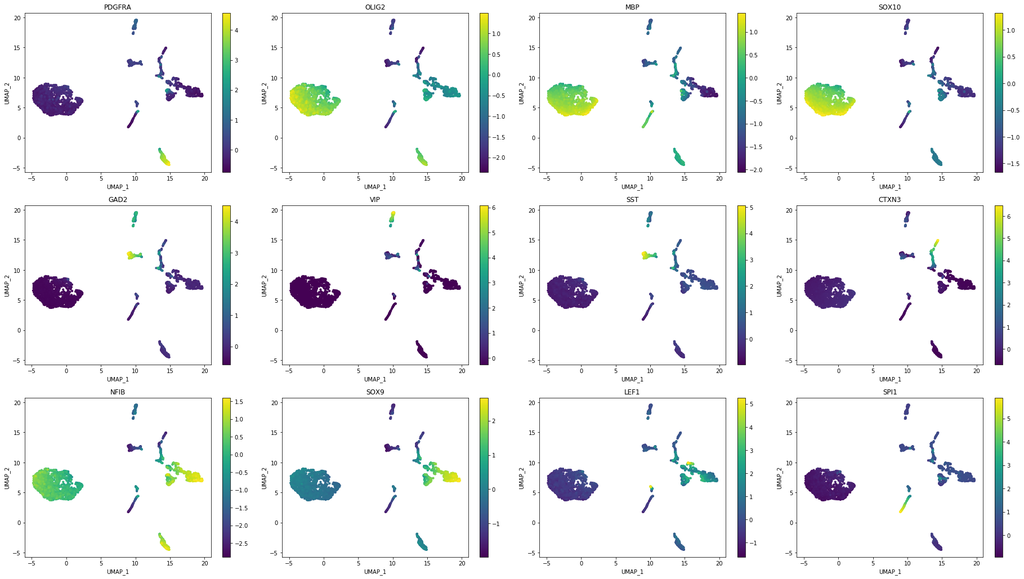

```python
#from pycisTopic.clust_vis import *
plot_imputed_features(cistopic_obj,
                    reduction_name='UMAP',
                    imputed_data=gene_act,
                    features=['PDGFRA', 'OLIG2', 'MBP', 'SOX10', # Olig differentiation
                              'GAD2', 'VIP', 'SST', 'CTXN3', # Int
                              'NFIB', 'SOX9',  #Ast
                              'LEF1', #Endo
                              'SPI1'], #Glia
                    scale=True,
                    num_columns=4,
                    save='/staging/leuven/stg_00002/lcb/cbravo/Multiomics_pipeline/analysis/10x_multiome_brain/output/atac/pycistopic/DAGs/example_best_DAGs.pdf')
```

How many DAGs do we have per cell type?

```python
x = [print(x + ': '+ str(len(markers_dict[x]))) for x in markers_dict.keys()]
```

```
AST: 2032
ASTP: 2013
AST_CER: 2457
ENDO: 1352
GC: 3061
GP: 3265
INH_PVALB: 2613
INH_SST: 2942
INH_VIP: 2816
MGL: 3243
MOL: 856
NFOL: 457
OPC: 1903
PURK: 3120
```

```python
# Save
with open('/staging/leuven/stg_00002/lcb/cbravo/Multiomics_pipeline/analysis/10x_multiome_brain/output/atac/pycistopic/DAGs/Gene_activity.pkl', 'wb') as f:
  pickle.dump(gene_act, f)
with open('/staging/leuven/stg_00002/lcb/cbravo/Multiomics_pipeline/analysis/10x_multiome_brain/output/atac/pycistopic/DAGs/DAGs.pkl', 'wb') as f:
  pickle.dump(markers_dict, f)
```

[Back to top]

### 13. Label transfer

```python
# Load cisTopic object
import pickle
infile = open('/staging/leuven/stg_00002/lcb/cbravo/Multiomics_pipeline/analysis/10x_multiome_brain/output/atac/pycistopic/10x_multiome_brain_cisTopicObject_noDBL.pkl', 'rb')
cistopic_obj = pickle.load(infile)
infile.close()
```

Exploting the gene activity scores, we can transfer labels from a reference data set (e.g. scRNA-seq). As an example, we will transfer labels from the scRNA-seq layer of this data set.

```python
# Create function to get metadata from loom (to add to loomxpy)
import pandas as pd
def get_metadata(loom):
    annot_metadata = loom.get_meta_data()['annotations']
    annot_mt_column_names = [annot_metadata[x]['name'] for x in range(len(annot_metadata))]
    annot_mt = pd.concat([pd.DataFrame(loom.col_attrs[annot_mt_column_names[x]]) for x in range(len(annot_mt_column_names))], axis=1)
    annot_mt.columns = [annot_mt_column_names[x] for x in range(len(annot_mt_column_names))]
    annot_mt.index = loom.get_cell_ids().tolist()
    return annot_mt
```

```python
# Prepare RNA
from loomxpy import SCopeLoom
import itertools
import anndata
path_to_loom = '/staging/leuven/stg_00002/lcb/cbravo/Multiomics_pipeline/analysis/10x_multiome_brain/output/rna/vsn/add_clusters_scrublet_as_annot/10x_multiome_brain_SCENIC_SCope_output_wAnnot_noDBL.loom'
loom = SCopeLoom.read_loom(path_to_loom)
metadata = get_metadata(loom)
expr_mat = loom.ex_mtx
rna_anndata = anndata.AnnData(X=expr_mat)
rna_anndata.obs = metadata
# Prepare ATAC
import pickle
infile = open('/staging/leuven/stg_00002/lcb/cbravo/Multiomics_pipeline/analysis/10x_multiome_brain/output/atac/pycistopic/DAGs/Gene_activity.pkl', 'rb') #Here I am using pycisTopic gene activity matrix, but could be any :)
gene_act = pickle.load(infile)
infile.close()
atac_anndata = anndata.AnnData(X=gene_act.mtx.T, obs=pd.DataFrame(index=gene_act.cell_names), var=pd.DataFrame(index=gene_act.feature_names))
```

The methods available for label transferring are: ingest' [from scanpy], 'harmony' [Korsunsky et al, 2019], 'bbknn' [Polański et al, 2020], 'scanorama' [Hie et al, 2019] and 'cca'. Except for ingest, these methods return a common coembedding and labels are inferred using the distances between query and refenrence cells as weights.

```python
from pycisTopic.label_transfer import *
label_dict = label_transfer(rna_anndata,
                  atac_anndata,
                  labels_to_transfer = ['cell_type'],
                  variable_genes = True,
                  methods = ['ingest', 'harmony', 'bbknn', 'scanorama', 'cca'],
                  return_label_weights = False)
```

```
2021-03-16 13:44:11,173 cisTopic     INFO     Normalizing RNA data
```

```
2021-03-16 13:44:23,051 cisTopic     INFO     Normalizing ATAC data
```

```
2021-03-16 13:44:31,039 cisTopic     INFO     Running integration with ingest
2021-03-16 13:44:45,106 cisTopic     INFO     Running integration with harmony
```

```
2021-03-16 13:44:46,231 harmonypy    INFO     Iteration 1 of 10
```

```
2021-03-16 13:44:47,896 - harmonypy - INFO - Iteration 2 of 10
```

```
2021-03-16 13:44:47,896 harmonypy    INFO     Iteration 2 of 10
```

```
2021-03-16 13:44:49,474 - harmonypy - INFO - Iteration 3 of 10
```

```
2021-03-16 13:44:49,474 harmonypy    INFO     Iteration 3 of 10
```

```
2021-03-16 13:44:51,098 - harmonypy - INFO - Iteration 4 of 10
```

```
2021-03-16 13:44:51,098 harmonypy    INFO     Iteration 4 of 10
```

```
2021-03-16 13:44:52,481 - harmonypy - INFO - Converged after 4 iterations
```

```
2021-03-16 13:44:52,481 harmonypy    INFO     Converged after 4 iterations
2021-03-16 13:44:52,555 cisTopic     INFO     Running integration with bbknn
```

```
2021-03-16 13:45:07,452 cisTopic     INFO     Running integration with scanorama
```

```
Found 1528 genes among all datasets
[[0.         0.27066336]
 [0.         0.        ]]
Processing datasets (0, 1)
2021-03-16 13:45:15,537 cisTopic     INFO     Running integration with cca
```

```python
label_dict_x=[label_dict[key] for key in label_dict.keys()]
label_pd = pd.concat(label_dict_x, axis=1, sort=False)
label_pd.index = cistopic_obj.cell_names
label_pd.columns = ['pycisTopic_' + x for x in label_pd.columns]
cistopic_obj.add_cell_data(label_pd)
```

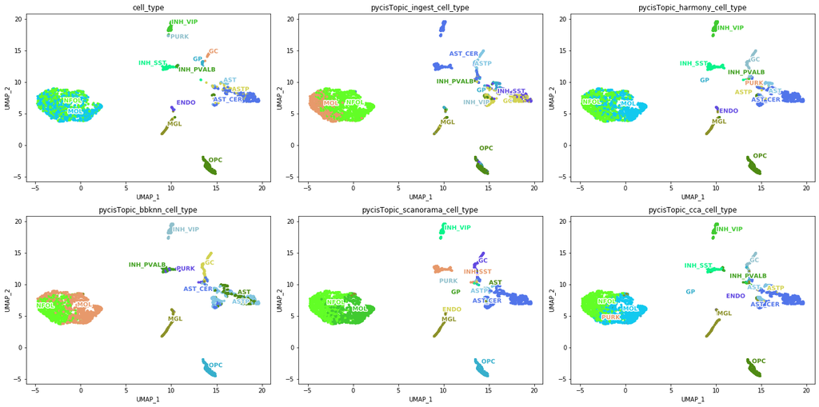

```python
from pycisTopic.clust_vis import *
plot_metadata(cistopic_obj,
             reduction_name='UMAP',
             variables=['cell_type'] + label_pd.columns.to_list(),
             remove_nan=True,
             cmap=cm.viridis,
             seed=555,
             num_columns=3,
             color_dictionary={},
             save='/staging/leuven/stg_00002/lcb/cbravo/Multiomics_pipeline/analysis/10x_multiome_brain/output/atac/pycistopic/DAGs/label_transfer.pdf')
```

```python
# Save
with open('/staging/leuven/stg_00002/lcb/cbravo/Multiomics_pipeline/analysis/10x_multiome_brain/output/atac/pycistopic/10x_multiome_brain_cisTopicObject_noDBL.pkl', 'wb') as f:
  pickle.dump(cistopic_obj, f)
```

[Back to top]

### 14. Exporting to loom

We can now create loom files to further explore the results. There are two types of loom files:

- **Region accessibility**: These loom files include the imputed accessibility as matrix, topics as regulons and cell-topic distributions as AUC matrices. The imputed values, the cistopic object used for the imputation and the cell-topic and topic-region binarized distributions are required. Alternatively, we can also provide different clustering and the marker regions (DARs) per group per clustering.
- **Gene activity**: These loom files contain the gene activity as matrix, scRNA-seq derived regulons and their AUC values based on gene activity. The gene activity values, the cistopic object, and scRNA-seq derived regulons are required. Alternatively, we can also provide different clustering and the marker genes (DAGs) per group per clustering.

In this case we will create 5 loom files: region accessibility and gene activity loom files containing all and only cells overlapping with the scRNA-seq data and a loom file using the actual gene expression values from the multiome.

We will first load the data we need for the region accessibility loom files.

```python
# Load cisTopic object
import pickle
infile = open('/staging/leuven/stg_00002/lcb/cbravo/Multiomics_pipeline/analysis/10x_multiome_brain/output/atac/pycistopic/10x_multiome_brain_cisTopicObject_noDBL.pkl', 'rb')
cistopic_obj = pickle.load(infile)
infile.close()
# Load imputed accessibility
import pickle
infile = open('/staging/leuven/stg_00002/lcb/cbravo/Multiomics_pipeline/analysis/10x_multiome_brain/output/atac/pycistopic/DARs/Imputed_accessibility.pkl', 'rb') #Here I am using pycisTopic gene activity matrix, but could be any :)
imputed_acc_obj = pickle.load(infile)
infile.close()
# Load region binarized topics
import pickle
infile = open('/staging/leuven/stg_00002/lcb/cbravo/Multiomics_pipeline/analysis/10x_multiome_brain/output/atac/pycistopic/topic_binarization/binarized_topic_region.pkl', 'rb') #Here I am using pycisTopic gene activity matrix, but could be any :)
binarized_topic_region = pickle.load(infile)
infile.close()
# Load cell binarized topics
import pickle
infile = open('/staging/leuven/stg_00002/lcb/cbravo/Multiomics_pipeline/analysis/10x_multiome_brain/output/atac/pycistopic/topic_binarization/binarized_cell_topic.pkl', 'rb') #Here I am using pycisTopic gene activity matrix, but could be any :)
binarized_cell_topic = pickle.load(infile)
infile.close()
# Load DARs
import pickle
infile = open('/staging/leuven/stg_00002/lcb/cbravo/Multiomics_pipeline/analysis/10x_multiome_brain/output/atac/pycistopic/DARs/DARs.pkl', 'rb')
DARs_dict = pickle.load(infile)
infile.close()
```

##### A. Region accessibility - All

```python
# Subset regions, we will use only regions in topics and DARs here to make it faster
regions_in_topics = list(set(sum([binarized_topic_region[i].index.tolist() for i in binarized_topic_region.keys()],[])))
regions_in_DARs = list(set(sum([DARs_dict[i].index.tolist() for i in DARs_dict.keys()],[])))
selected_regions = list(set(regions_in_topics + regions_in_DARs))
# Prepare DARs dict
cluster_markers = {'cell_type': DARs_dict}
# Export to loom
from pycisTopic.loom import *
export_region_accessibility_to_loom(accessibility_matrix = imputed_acc_obj,
                  cistopic_obj = cistopic_obj,
                  binarized_topic_region = binarized_topic_region,
                  binarized_cell_topic = binarized_cell_topic,
                  out_fname = '/staging/leuven/stg_00002/lcb/cbravo/Multiomics_pipeline/analysis/10x_multiome_brain/output/atac/pycistopic/loom/cell_region-all.loom',
                  selected_regions = selected_regions ,
                  selected_cells = None,
                  cluster_annotation = ['cell_type'],
                  cluster_markers = cluster_markers,
                  tree_structure = ('10x_multiome_brain', 'pycisTopic', 'noDBL_all'),
                  title = 'Tutorial - Region accessibility all',
                  nomenclature = "mm10")
```

```
2021-03-18 10:00:49,484 cisTopic     INFO     Creating minimal loom
Regulon name does not seem to be compatible with SCOPE. It should include a space to allow selection of the TF.
Please run:
 regulons = [r.rename(r.name.replace('(+)',' ('+str(len(r))+'g)')) for r in regulons]
or:
 regulons = [r.rename(r.name.replace('(',' (')) for r in regulons]
2021-03-18 10:08:37,899 cisTopic     INFO     Adding annotations
2021-03-18 10:08:50,333 cisTopic     INFO     Adding clusterings
2021-03-18 10:08:50,384 cisTopic     INFO     Adding markers
No markers for  nan
2021-03-18 10:08:53,971 cisTopic     INFO     Exporting
```

##### B. Region accessibility - Only cells in scRNA-seq

```python
# Get metadata from high-quality loom file
from pycisTopic.loom import *
path_to_annotated_rna_loom = "/staging/leuven/stg_00002/lcb/cbravo/Multiomics_pipeline/analysis/10x_multiome_brain/output/rna/vsn/add_clusters_scrublet_as_annot/10x_multiome_brain_SCENIC_SCope_output_wAnnot_noDBL.loom"
loom = SCopeLoom.read_loom(path_to_annotated_rna_loom)
cell_data = get_metadata(loom)
selected_cells = list(set(cistopic_obj.cell_names) & set(cell_data.index.to_list()))
# Add RNA embeddings
embeddings_ids = [loom.get_meta_data()['embeddings'][x]['id'] for x in range(len(loom.get_meta_data()['embeddings']))]
embeddings = {loom.get_meta_data()['embeddings'][x]['name']: pd.DataFrame(loom.get_embedding_by_id(embeddings_ids[x]), index=cell_data.index.to_list()) for x in range(len(embeddings_ids))}
rna_cistopic_obj = cistopic_obj
rna_cistopic_obj.projections['cell'].update(embeddings)
```

```python
export_region_accessibility_to_loom(accessibility_matrix = imputed_acc_obj,
                  cistopic_obj = rna_cistopic_obj,
                  binarized_topic_region = binarized_topic_region,
                  binarized_cell_topic = binarized_cell_topic,
                  out_fname = '/staging/leuven/stg_00002/lcb/cbravo/Multiomics_pipeline/analysis/10x_multiome_brain/output/atac/pycistopic/loom/cell_region-wRNA.loom',
                  selected_regions = selected_regions,
                  selected_cells = selected_cells,
                  cluster_annotation = ['cell_type'],
                  cluster_markers = cluster_markers,
                  tree_structure = ('10x_multiome_brain', 'pycisTopic', 'noDBL_all'),
                  title = 'Tutorial - Region accessibility',
                  nomenclature = "mm10")
```

```
2021-03-18 11:27:46,755 cisTopic     INFO     Creating minimal loom
Regulon name does not seem to be compatible with SCOPE. It should include a space to allow selection of the TF.
Please run:
 regulons = [r.rename(r.name.replace('(+)',' ('+str(len(r))+'g)')) for r in regulons]
or:
 regulons = [r.rename(r.name.replace('(',' (')) for r in regulons]
2021-03-18 11:35:09,290 cisTopic     INFO     Adding annotations
2021-03-18 11:35:19,203 cisTopic     INFO     Adding clusterings
2021-03-18 11:35:19,240 cisTopic     INFO     Adding markers
2021-03-18 11:35:22,662 cisTopic     INFO     Exporting
```

##### C. Gene activity - All

```python
# Load cisTopic object
import pickle
infile = open('/staging/leuven/stg_00002/lcb/cbravo/Multiomics_pipeline/analysis/10x_multiome_brain/output/atac/pycistopic/10x_multiome_brain_cisTopicObject_noDBL.pkl', 'rb')
cistopic_obj = pickle.load(infile)
infile.close()
# Get regulons
path_to_annotated_rna_loom = "/staging/leuven/stg_00002/lcb/cbravo/Multiomics_pipeline/analysis/10x_multiome_brain/output/rna/vsn/add_clusters_scrublet_as_annot/10x_multiome_brain_SCENIC_SCope_output_wAnnot_noDBL.loom"
loom = SCopeLoom.read_loom(path_to_annotated_rna_loom)
regulons = get_regulons(loom)
# Get gene activity
import pickle
infile = open('/staging/leuven/stg_00002/lcb/cbravo/Multiomics_pipeline/analysis/10x_multiome_brain/output/atac/pycistopic/DAGs/Gene_activity.pkl', 'rb') #Here I am using pycisTopic gene activity matrix, but could be any :)
gene_act = pickle.load(infile)
infile.close()
# Get DAGs
import pickle
infile = open('/staging/leuven/stg_00002/lcb/cbravo/Multiomics_pipeline/analysis/10x_multiome_brain/output/atac/pycistopic/DAGs/DAGs.pkl', 'rb')
DAGs_dict = pickle.load(infile)
infile.close()
cluster_markers = {'cell_type': DAGs_dict}
# Run function
export_gene_activity_to_loom(gene_activity_matrix = gene_act,
                  cistopic_obj = cistopic_obj,
                  regulons = regulons,
                  out_fname = '/staging/leuven/stg_00002/lcb/cbravo/Multiomics_pipeline/analysis/10x_multiome_brain/output/atac/pycistopic/loom/cell_gene-all.loom',
                  cluster_annotation = ['cell_type'],
                  cluster_markers = cluster_markers,
                  tree_structure = ('10x_multiome_brain', 'pycisTopic', 'noDBL_all'),
                  title = 'Tutorial - Gene activity',
                  nomenclature = "mm10")
```

```
2021-03-18 11:41:53,780 cisTopic     INFO     Creating minimal loom
Regulon name does not seem to be compatible with SCOPE. It should include a space to allow selection of the TF.
Please run:
 regulons = [r.rename(r.name.replace('(+)',' ('+str(len(r))+'g)')) for r in regulons]
or:
 regulons = [r.rename(r.name.replace('(',' (')) for r in regulons]
```

```
2021-03-18 11:42:07,866 - pyscenic.recovery - WARNING - Less than 80% of the genes in HNF1B_(+) are present in the expression matrix.
```

```
2021-03-18 11:42:07,866 pyscenic.recovery WARNING  Less than 80% of the genes in HNF1B_(+) are present in the expression matrix.
```

```
2021-03-18 11:42:08,708 - pyscenic.recovery - WARNING - Less than 80% of the genes in MYBL1_(+) are present in the expression matrix.
```

```
2021-03-18 11:42:08,708 pyscenic.recovery WARNING  Less than 80% of the genes in MYBL1_(+) are present in the expression matrix.
```

```
2021-03-18 11:42:09,454 - pyscenic.recovery - WARNING - Less than 80% of the genes in HIC2_(+) are present in the expression matrix.
```

```
2021-03-18 11:42:09,454 pyscenic.recovery WARNING  Less than 80% of the genes in HIC2_(+) are present in the expression matrix.
```

```
2021-03-18 11:42:09,706 - pyscenic.recovery - WARNING - Less than 80% of the genes in LHX4_(+) are present in the expression matrix.
```

```
2021-03-18 11:42:09,706 pyscenic.recovery WARNING  Less than 80% of the genes in LHX4_(+) are present in the expression matrix.
```

```
2021-03-18 11:42:09,908 - pyscenic.recovery - WARNING - Less than 80% of the genes in ZNF625_(+) are present in the expression matrix.
```

```
2021-03-18 11:42:09,908 pyscenic.recovery WARNING  Less than 80% of the genes in ZNF625_(+) are present in the expression matrix.
```

```
2021-03-18 11:42:10,427 - pyscenic.recovery - WARNING - Less than 80% of the genes in PAX3_(+) are present in the expression matrix.
```

```
2021-03-18 11:42:10,427 pyscenic.recovery WARNING  Less than 80% of the genes in PAX3_(+) are present in the expression matrix.
2021-03-18 11:47:13,806 cisTopic     INFO     Adding annotations
2021-03-18 11:47:16,144 cisTopic     INFO     Adding clusterings
2021-03-18 11:47:16,190 cisTopic     INFO     Adding markers
No markers for  nan
2021-03-18 11:47:16,708 cisTopic     INFO     Exporting
```

##### D. Gene activity - Only cells in scRNA-seq

```python
export_gene_activity_to_loom(gene_activity_matrix = gene_act,
                  cistopic_obj = rna_cistopic_obj,
                  regulons = regulons,
                  selected_cells = selected_cells,
                  out_fname = '/staging/leuven/stg_00002/lcb/cbravo/Multiomics_pipeline/analysis/10x_multiome_brain/output/atac/pycistopic/loom/cell_gene-wRNA.loom',
                  cluster_annotation = ['cell_type'],
                  cluster_markers = cluster_markers,
                  tree_structure = ('10x_multiome_brain', 'pycisTopic', 'noDBL_all'),
                  title = 'Tutorial - Gene activity',
                  nomenclature = "mm10")
```

```
2021-03-18 11:51:51,992 cisTopic     INFO     Creating minimal loom
Regulon name does not seem to be compatible with SCOPE. It should include a space to allow selection of the TF.
Please run:
 regulons = [r.rename(r.name.replace('(+)',' ('+str(len(r))+'g)')) for r in regulons]
or:
 regulons = [r.rename(r.name.replace('(',' (')) for r in regulons]
```

```
2021-03-18 11:52:05,461 - pyscenic.recovery - WARNING - Less than 80% of the genes in HNF1B_(+) are present in the expression matrix.
```

```
2021-03-18 11:52:05,461 pyscenic.recovery WARNING  Less than 80% of the genes in HNF1B_(+) are present in the expression matrix.
```

```
2021-03-18 11:52:05,482 - pyscenic.recovery - WARNING - Less than 80% of the genes in LHX4_(+) are present in the expression matrix.
```

```
2021-03-18 11:52:05,482 pyscenic.recovery WARNING  Less than 80% of the genes in LHX4_(+) are present in the expression matrix.
```

```
2021-03-18 11:52:06,990 - pyscenic.recovery - WARNING - Less than 80% of the genes in MYBL1_(+) are present in the expression matrix.
```

```
2021-03-18 11:52:06,990 pyscenic.recovery WARNING  Less than 80% of the genes in MYBL1_(+) are present in the expression matrix.
```

```
2021-03-18 11:52:07,286 - pyscenic.recovery - WARNING - Less than 80% of the genes in HIC2_(+) are present in the expression matrix.
```

```
2021-03-18 11:52:07,286 pyscenic.recovery WARNING  Less than 80% of the genes in HIC2_(+) are present in the expression matrix.
```

```
2021-03-18 11:52:07,381 - pyscenic.recovery - WARNING - Less than 80% of the genes in PAX3_(+) are present in the expression matrix.
```

```
2021-03-18 11:52:07,381 pyscenic.recovery WARNING  Less than 80% of the genes in PAX3_(+) are present in the expression matrix.
```

```
2021-03-18 11:52:07,384 - pyscenic.recovery - WARNING - Less than 80% of the genes in ZNF625_(+) are present in the expression matrix.
```

```
2021-03-18 11:52:07,384 pyscenic.recovery WARNING  Less than 80% of the genes in ZNF625_(+) are present in the expression matrix.
2021-03-18 11:56:47,439 cisTopic     INFO     Adding annotations
2021-03-18 11:56:49,265 cisTopic     INFO     Adding clusterings
2021-03-18 11:56:49,300 cisTopic     INFO     Adding markers
2021-03-18 11:56:49,793 cisTopic     INFO     Exporting
```

##### E. Gene expression - Add pycisTopic dimensionality reduction

```python
# Get DGEM
path_to_annotated_rna_loom = "/staging/leuven/stg_00002/lcb/cbravo/Multiomics_pipeline/analysis/10x_multiome_brain/output/rna/vsn/add_clusters_scrublet_as_annot/10x_multiome_brain_SCENIC_SCope_output_wAnnot_noDBL.loom"
loom = SCopeLoom.read_loom(path_to_annotated_rna_loom)
dgem = loom.ex_mtx
# Create loom
export_gene_activity_to_loom(gene_activity_matrix = dgem,
                  cistopic_obj = rna_cistopic_obj,
                  regulons = regulons,
                  selected_cells = selected_cells,
                  out_fname = '/staging/leuven/stg_00002/lcb/cbravo/Multiomics_pipeline/analysis/10x_multiome_brain/output/atac/pycistopic/loom/gene_expression.loom',
                  cluster_annotation = ['cell_type'],
                  cluster_markers = None,
                  tree_structure = ('10x_multiome_brain', 'pycisTopic', 'noDBL_all'),
                  title = 'Tutorial - Gene expression',
                  nomenclature = "mm10")
```

```
2021-03-18 12:03:43,213 cisTopic     INFO     Creating minimal loom
Regulon name does not seem to be compatible with SCOPE. It should include a space to allow selection of the TF.
Please run:
 regulons = [r.rename(r.name.replace('(+)',' ('+str(len(r))+'g)')) for r in regulons]
or:
 regulons = [r.rename(r.name.replace('(',' (')) for r in regulons]
2021-03-18 12:13:22,085 cisTopic     INFO     Adding annotations
2021-03-18 12:13:23,165 cisTopic     INFO     Adding clusterings
2021-03-18 12:13:23,202 cisTopic     INFO     Exporting
```

[Back to top]